# Analysis in R

Sarah Wellberg

Most the the examples use a 20-item test with 1000 respondents. The first 10 rows are printed below:

Table continues below

| q1 | q2 | q3 | q4 | q5 | q6 | q7 | q8 | q9 | q10 | q11 | q12 | q13 | q14 | q15 |
| --- | --- | --- | --- | --- | --- | --- | --- | --- | --- | --- | --- | --- | --- | --- |
| 1 | 1 | 0 | 1 | 1 | 0 | 0 | 0 | 0 | 0 | 1 | 0 | 0 | 0 | 1 |
| 1 | 1 | 0 | 1 | 1 | 1 | 0 | 1 | 1 | 1 | 0 | 1 | 1 | 1 | 1 |
| 1 | 0 | 0 | 1 | 0 | 0 | 0 | 1 | 1 | 0 | 0 | 0 | 0 | 0 | 1 |
| 1 | 1 | 0 | 0 | 0 | 1 | 0 | 1 | 1 | 1 | 1 | 1 | 0 | 0 | 1 |
| 0 | 1 | 1 | 1 | 0 | 0 | 0 | 0 | 0 | 0 | 0 | 0 | 0 | 0 | 0 |
| 1 | 0 | 1 | 1 | 1 | 1 | 1 | 0 | 1 | 1 | 1 | 1 | 1 | 1 | 1 |
| 1 | 0 | 0 | 1 | 1 | 1 | 0 | 1 | 0 | 0 | 0 | 1 | 1 | 1 | 0 |
| 0 | 1 | 0 | 0 | 0 | 0 | 0 | 0 | 1 | 0 | 0 | 0 | 0 | 1 | 1 |
| 0 | 1 | 1 | 1 | 1 | 0 | 1 | 1 | 1 | 1 | 1 | 1 | 1 | 1 | 1 |
| 1 | 1 | 0 | 1 | 0 | 0 | 0 | 0 | 0 | 0 | 0 | 0 | 0 | 1 | 1 |

| q16 | q17 | q18 | q19 | q20 |
| --- | --- | --- | --- | --- |
| 0 | 0 | 0 | 0 | 0 |
| 1 | 1 | 1 | 1 | 1 |
| 1 | 0 | 1 | 1 | 1 |
| 1 | 1 | 1 | 1 | 1 |
| 0 | 0 | 0 | 0 | 0 |
| 0 | 0 | 1 | 1 | 1 |
| 0 | 1 | 0 | 0 | 1 |
| 0 | 0 | 0 | 1 | 0 |
| 0 | 1 | 1 | 1 | 1 |
| 0 | 1 | 1 | 1 | 1 |

Other examples use a set of pre-test and post-test scores for 100 students (the same data set used in the Visualizations in R file).

## Descriptives

The following are basic descriptive statistics to help you get to know your data.

### Frequency

#### One Vector

1. Quick Count

If you just want a quick count using base R, use the `table` function.

*Code*: `table(vector)`

*Example*:

Let’s get a count of how many students earned which score on the pre-test.

```r
table(scores$pre)
```

```
##
## 12 13 14 15 16 17 18 19 20 21 22 23 24 25 26 27 29
##  1  1  1  5 10  8  9 11 11 13 11  7  5  1  4  1  1
```

2. Data Frame

The `count` function is in the **plyr** package and returns a data frame with the unique entires of a vector as one column and their frequencies as another column.

*Warnings*:

- There is also a function called `count` in the **dplyr** package, so you’ll need to specify which one you want if you have both packages loaded.
- If the entires you’re counting are numeric, the resulting data frame will be arranged numerically. If your entries are characters or factors, they will be arranged in the order in which they appear in the vector. Be careful if you’re combining frequencies for multiple vectors, as the orders may be different.

*Code*:

If **dplyr** is not loaded: `freq_df <- count(vector)`

If **dplyr** is loaded: `freq_df <- plyr::count(vector)`

*Example*:

Let’s get the frequencies of responses for the first item of our test.

```r
q1_count <- plyr::count(test$q1)
```

| x | freq |
| --- | --- |
| 0 | 314 |
| 1 | 686 |

#### Get counts for all items

1. Numeric entries

We can use a for loop to get the frequencies for all items in one big table. Since `count` returns a data frame, and the order will always be numeric, we take the second column as the columns for a larger frequency table.

*Code*:

```
# Make blank table
  freq_table <- data.frame(matrix(NA, nrow = options_num, ncol = items_num))

# Get frequencies
  for (variable in 1:ncol(df)) {
    freq_table[,variable] <- plyr::count(df[,variable])[,2]
  }

# Change names
  names(freq_table) <- names(df)
  row.names(freq_table) <- options_vector
```

*Horizontal Example*:

Let’s make a frequency table for the dichotomous responses in the *test* data frame.

```r
# Make blank table
  test_freq <- data.frame(matrix(NA, nrow = 2, ncol = 20))

# Get frequencies
  for (i in 1:20) {
    test_freq[,i] <- plyr::count(test[,i])[,2]
  }

# Change names
  names(test_freq) <- names(test)
  row.names(test_freq) <- 0:1
```

Table continues below

|  | q1 | q2 | q3 | q4 | q5 | q6 | q7 | q8 | q9 | q10 | q11 | q12 |
| --- | --- | --- | --- | --- | --- | --- | --- | --- | --- | --- | --- | --- |
| **0** | 314 | 475 | 554 | 375 | 476 | 756 | 620 | 319 | 542 | 795 | 663 | 577 |
| **1** | 686 | 525 | 446 | 625 | 524 | 244 | 380 | 681 | 458 | 205 | 337 | 423 |

|  | q13 | q14 | q15 | q16 | q17 | q18 | q19 | q20 |
| --- | --- | --- | --- | --- | --- | --- | --- | --- |
| **0** | 642 | 467 | 353 | 768 | 701 | 370 | 444 | 257 |
| **1** | 358 | 533 | 647 | 232 | 299 | 630 | 556 | 743 |

*Vertical Example*:

You can make the table vertical with items as rows and 0-1 frequencies as columns by:

- Swapping the nrow and ncol values
- Using the code `test_freq[i,]` to assign values
- Swapping the names and row.names code

```r
# Make blank table
  test_freq_vert <- data.frame(matrix(NA, nrow = 20, ncol = 2))

# Get frequencies
  for (i in 1:20) {
    test_freq_vert[i,] <- plyr::count(test[,i])[,2]
  }

# Change names
  row.names(test_freq_vert) <- names(test)
  names(test_freq_vert) <- 0:1
```

|  | 0 | 1 |
| --- | --- | --- |
| **q1** | 314 | 686 |
| **q2** | 475 | 525 |
| **q3** | 554 | 446 |
| **q4** | 375 | 625 |
| **q5** | 476 | 524 |
| **q6** | 756 | 244 |
| **q7** | 620 | 380 |
| **q8** | 319 | 681 |
| **q9** | 542 | 458 |
| **q10** | 795 | 205 |
| **q11** | 663 | 337 |
| **q12** | 577 | 423 |
| **q13** | 642 | 358 |
| **q14** | 467 | 533 |
| **q15** | 353 | 647 |
| **q16** | 768 | 232 |
| **q17** | 701 | 299 |
| **q18** | 370 | 630 |
| **q19** | 444 | 556 |
| **q20** | 257 | 743 |

2. Character entries

The response order will be different for each item, so you can’t use the approach above and expect the numbers to match the correct response. You can either use the approach demonstrated in the Functions section of the R Basics file, or you can use the `full_join` command to match the response order from different data frames. The `count` function gives the entries column the name `"x"`, so you’ll want to use that for your response vector.

We’ll use a temperary data frame to get the responses and counts. It’ll change with each iteration of the loop. You can remove it at the end if you don’t want it in your global environment, but you don’t have to.

*Code*:

```
# Start the table with the response order
  freq_table <- data.frame(resp_vector)

# Get item counts, and joint them to the existing table
  for (variable in 1:ncol(df)) {
    temp <- plyr::count(df[,variable])

    freq_table <- full_join(by = "x", freq_table, temp)

    # Make NA's 0 and keep the rest as-is
    freq_table[,i+1] <- ifelse(is.na(freq_table[,i+1]),
                               0,
                               freq_table[,i+1])
  }

# Rename
  row.names(freq_table) <- freq_table$x
  freq_table$x <- NULL

  names(freq_table) <- names(df)

# Remove temp data frame (optional)
  rm(temp)
  }
```

```r
# Start the table with the response order
  likert_freq <- data.frame(x = c("Completely Agree",
                                  "Somewhat Agree",
                                  "Somewhat Disagree",
                                  "Completely Disagree"))

# Get item counts, and joint them to the existing table
  for (i in 1:6) {
    temp <- plyr::count(likert[,i])

    likert_freq <- full_join(by = "x", likert_freq, temp)

    # Make NA's 0 and keep the rest as-is
    likert_freq[,i+1] <- ifelse(is.na(likert_freq[,i+1]),
                                0,
                                likert_freq[,i+1])
  }

# Rename
  row.names(likert_freq) <- likert_freq$x
  likert_freq$x <- NULL

  names(likert_freq) <- names(likert)

# Remove temp data frame (optional)
  rm(temp)
```

|  | s1 | s2 | s3 | s4 | s5 | s6 |
| --- | --- | --- | --- | --- | --- | --- |
| **Completely Agree** | 2 | 0 | 3 | 1 | 1 | 3 |
| **Somewhat Agree** | 2 | 1 | 2 | 3 | 5 | 4 |
| **Somewhat Disagree** | 4 | 6 | 0 | 2 | 1 | 2 |
| **Completely Disagree** | 2 | 3 | 5 | 4 | 3 | 1 |

### Density

To get densities, just divide each entry in your frequency table by the number of observations in your data frame.

Keep in mind that you may need to round the numbers to look nice in a table

*Code*:

```
# Copy frequency data frame (unless you don't want to keep it for some reason)
  density_table <- freq_table

for (variable in 1:ncol(density_table)) {
  density_table[,i] <- round(density_table[,i] / nrow(df), decimal_places)
}
```

*Example*:

Let’s find the proportions for the likert frequency table we made.

```r
# Copy frequency table
  likert_density <- likert_freq

for (i in 1:6) {
  likert_density[,i] <- round(likert_density[,i] / nrow(likert), 1)
}
```

|  | s1 | s2 | s3 | s4 | s5 | s6 |
| --- | --- | --- | --- | --- | --- | --- |
| **Completely Agree** | 0.2 | 0 | 0.3 | 0.1 | 0.1 | 0.3 |
| **Somewhat Agree** | 0.2 | 0.1 | 0.2 | 0.3 | 0.5 | 0.4 |
| **Somewhat Disagree** | 0.4 | 0.6 | 0 | 0.2 | 0.1 | 0.2 |
| **Completely Disagree** | 0.2 | 0.3 | 0.5 | 0.4 | 0.3 | 0.1 |

### Cross-Tabulations

Use the `table` function to return a cross-tabulation.

*Code*: `table(df)`

*Example*:

Lets get a cross-tab for the pre-and post-test scores.

```r
table(scores)
```

```
##     post
## pre  23 24 25 26 27 28 29 30 31 32 33 34 35 36 37 38 39 40 41 45
##   12  0  0  1  0  0  0  0  0  0  0  0  0  0  0  0  0  0  0  0  0
##   13  1  0  0  0  0  0  0  0  0  0  0  0  0  0  0  0  0  0  0  0
##   14  0  0  0  1  0  0  0  0  0  0  0  0  0  0  0  0  0  0  0  0
##   15  1  0  1  1  0  1  0  1  0  0  0  0  0  0  0  0  0  0  0  0
##   16  0  1  1  1  0  2  1  2  1  0  1  0  0  0  0  0  0  0  0  0
##   17  0  0  0  0  2  0  3  1  0  2  0  0  0  0  0  0  0  0  0  0
##   18  0  0  0  0  0  3  2  2  2  0  0  0  0  0  0  0  0  0  0  0
##   19  0  0  0  0  0  1  0  2  2  6  0  0  0  0  0  0  0  0  0  0
##   20  0  0  0  0  0  0  1  3  0  1  4  2  0  0  0  0  0  0  0  0
##   21  0  0  0  0  0  0  1  1  1  1  2  4  0  2  1  0  0  0  0  0
##   22  0  0  0  0  0  0  0  1  1  0  3  2  1  2  1  0  0  0  0  0
##   23  0  0  0  0  0  0  0  0  0  0  3  0  1  1  0  1  0  1  0  0
##   24  0  0  0  0  0  0  0  0  0  0  1  0  1  0  0  2  0  0  1  0
##   25  0  0  0  0  0  0  0  0  0  0  0  0  1  0  0  0  0  0  0  0
##   26  0  0  0  0  0  0  0  0  0  0  0  0  0  0  0  0  2  1  0  1
##   27  0  0  0  0  0  0  0  0  0  0  0  0  0  0  0  0  0  0  1  0
##   29  0  0  0  0  0  0  0  0  0  0  0  0  0  0  0  0  1  0  0  0
```

### Summary Stats

The easiest way to get quick summary statistics is by using the `summary` command. It’ll give you the quartiles and the mean of numeric data in a table format. This does not create a data frame, but you can assign summary results to an empty one.

#### Quick Summaries

1. One vector

*Code*: `summary(vector)`

*Example*:

```r
summary(scores$pre)
```

```
##    Min. 1st Qu.  Median    Mean 3rd Qu.    Max.
##   12.00   17.00   20.00   19.82   22.00   29.00
```

2. Summarizing a data frame

You can enter the name of a data frame as the argument, and it’ll print the summary stats for each variable.

*Code*: `summary(df)`

*Example*:

```r
summary(scores)
```

```
##       pre             post
##  Min.   :12.00   Min.   :23.00
##  1st Qu.:17.00   1st Qu.:29.00
##  Median :20.00   Median :32.00
##  Mean   :19.82   Mean   :31.98
##  3rd Qu.:22.00   3rd Qu.:34.00
##  Max.   :29.00   Max.   :45.00
```

#### Making a Summary Table

If you want to create a table of summary statistics for multiple variables, assign the summary for each variable to a row or column of an empty data frame.

1. Variables as rows

*Code*:

```
# Create empty data frame
  stat_table <- data.frame(matrix(NA, nrow = variable_num, ncol = 6))

# Get summary values
  for (i in 1:variable_num) {
    stat_table[i,] <- summary(df[,i])
  }

# Change names
```

Or, if you only want some variables from the data frame:

```
# Create empty data frame
  stat_table <- data.frame(matrix(NA, nrow = variable_num, ncol = 6))

# Make a vector of variables you want stats for
  var_list <- vector_of_var_names

# Get summary values
  for (i in 1:length(vars)) {
    var <- var_list[i]
    stat_table[i,] <- summary(df[[var]])
  }

# Change names
```

*Whole Data Frame Example*:

Let’s get summary stats for the each item in the likert frequency table.

```r
# Create empty data frame
  freq_stats <- data.frame(matrix(NA, nrow = 6, ncol = 6))

# Get summary values
  for (i in 1:6) {
    freq_stats[i,] <- summary(likert_freq[,i])
  }

# Change names:
  names(freq_stats) <- c("min", "q2", "median", "mean", "q3", "max")
  row.names(freq_stats) <- names(likert_freq)
```

|  | min | q2 | median | mean | q3 | max |
| --- | --- | --- | --- | --- | --- | --- |
| **s1** | 2 | 2 | 2 | 2.5 | 2.5 | 4 |
| **s2** | 0 | 0.75 | 2 | 2.5 | 3.75 | 6 |
| **s3** | 0 | 1.5 | 2.5 | 2.5 | 3.5 | 5 |
| **s4** | 1 | 1.75 | 2.5 | 2.5 | 3.25 | 4 |
| **s5** | 1 | 1 | 2 | 2.5 | 3.5 | 5 |
| **s6** | 1 | 1.75 | 2.5 | 2.5 | 3.25 | 4 |

*Certain Variables Example*:

Maybe we only want the stats for some columns in our data frame. Let’s get stats for statements 1, 3, 5, & 6 in the likert frequency data frame.

Note the difference in the row names code.

```r
# Create empty data frame
  freq_stats <- data.frame(matrix(NA, nrow = 4, ncol = 6))

# Variable names
  var_list <- c("s1", "s3", "s5", "s6")

# Get summary values
  for (i in 1:length(var_list)) {
    var <- var_list[i]

    freq_stats[i,] <- summary(likert_freq[[var]])
  }

# Change names:
  names(freq_stats) <- c("min", "q2", "median", "mean", "q3", "max")
  row.names(freq_stats) <- var_list
```

|  | min | q2 | median | mean | q3 | max |
| --- | --- | --- | --- | --- | --- | --- |
| **s1** | 2 | 2 | 2 | 2.5 | 2.5 | 4 |
| **s3** | 0 | 1.5 | 2.5 | 2.5 | 3.5 | 5 |
| **s5** | 1 | 1 | 2 | 2.5 | 3.5 | 5 |
| **s6** | 1 | 1.75 | 2.5 | 2.5 | 3.25 | 4 |

2. Variables as columns

The code is the same as for making the variables as rows, you just change the assignment index and the names and row.names code.

*Example*

Let’s make a vertical summary stats data frame of the pre- and post-test scores.

```r
# Create empty data frame
  score_stats <- data.frame(matrix(NA, nrow = 6, ncol = 2))

# Get summary values
  for (i in 1:2) {
    score_stats[,i] <- summary(scores[,i])
  }

# Change names:
  row.names(score_stats) <- c("min", "q2", "median", "mean", "q3", "max")
  names(score_stats) <- names(scores)
```

|  | pre | post |
| --- | --- | --- |
| **min** | 12 | 23 |
| **q2** | 17 | 29 |
| **median** | 20 | 32 |
| **mean** | 19.82 | 31.98 |
| **q3** | 22 | 34 |
| **max** | 29 | 45 |

#### Handeling NA’s

The summary command will tell you how many entries in your vector are NA.

*Example*:

```r
na_data <- c(1, 2, 3, 4, 5, NA, NA, 8)

summary(na_data)
```

```
##    Min. 1st Qu.  Median    Mean 3rd Qu.    Max.    NA's
##   1.000   2.250   3.500   3.833   4.750   8.000       2
```

### Individual Stats

Sometimes you only want one kind of statistic, or you want to pick which ones you include in a table.

**Warning**: If you have missing data, these will return NA. You need to use the `na.rm = TRUE` option to ignore them.

*NA Example*:

```r
mean(na_data)
```

```
## [1] NA
```

```r
mean(na_data, na.rm = TRUE)
```

```
## [1] 3.833333
```

#### Center

1. Mean

*Code* `mean(vector)`

2. Median

*Code*: `median(vector)`

#### Spread

1. Standard Deviation

*Code*: `sd(vector)`

2. Interquartile range

*Code*: `IQR(vector)`

#### Range

1. Minimum

*Code*: `min(vector)`

2. Maximum

*Code*: `max(vector)`

3. Quartiles

Use the `quantile` function to get quartiles. You can get all five quartile values or only certain ones by specifying which you want in the `probs` option.

*Code*: `quantile(vector, probs = values)`

*All Values Example*:

Lets find the quartile values for the pre-test scores.

```r
quantile(scores$pre,
         probs = seq(0, 1, 0.25)) # go from 0 to 1 in increments of 0.25
```

```
##   0%  25%  50%  75% 100%
##   12   17   20   22   29
```

*Only Q1 and Q3 Example*:

Lets find the first and third quartile values for the pre-test scores.

```r
quantile(scores$pre,
         probs = c(0.25, 0.75))
```

```
## 25% 75%
##  17  22
```

### Stats by Variable Grouping

If you want to get summary stats for each subgroup of a data set, use the `group_by` and `summarize` commands in the **dplyr** package. It’ll make a new data frame with the unique grouping variable values as the first column and the listed stats as the following columns.

*Code*:

```
sum_table <- df %>%
                group_by(grouping_var) %>%
                summarize(col_name1 = stat1(sum_var),
                          col_name2 = stat2(sum_var), ...) %>%
                ungroup()
```

*Example*:

Let’s use the *data* data frame printed below to find the mean and SD for the “score” variable for each teacher.

| id | score | grade | color | teacher |
| --- | --- | --- | --- | --- |
| s100 | 85 | 10 | red | Mr. Stangl |
| s200 | 95 | 10 | orange | Ms. Wellberg |
| s300 | 90 | 9 | yellow | Ms. Wellberg |
| s400 | 80 | 9 | green | Mr. Stangl |
| s500 | 70 | 10 | blue | Mr. Stangl |
| s600 | 75 | 9 | purple | Ms. Wellberg |

```r
teacher_sum <- data %>%
                    group_by(teacher) %>%
                    summarize(mean = mean(score),
                              sd = sd(score)) %>%
                    ungroup()
```

| teacher | mean | sd |
| --- | --- | --- |
| Mr. Stangl | 78.33 | 7.638 |
| Ms. Wellberg | 86.67 | 10.41 |

## Regressions

Regressions in R all have the same structure, and you can save them as objects to call on whatever regression stats you need.

### Linear

#### Simple Regression

*Code*: `lm(y ~ x)`

*Example*:

Let’s regress post-test scores on pre-test scores.

```r
scores_reg <- lm(sg$post ~ sg$pre)
```

```
##
## Call:
## lm(formula = sg$post ~ sg$pre)
##
## Coefficients:
## (Intercept)       sg$pre
##      10.443        1.087
```

#### Multiple Regression

You can add as many predictor variables as you’d like after the `~`.

*Code*: `lm(y ~ x1 + x2 + ...)`

*Example*:

We have the grade level for each student who took the pre- and post-tests. These are in a new data frame called *sg*. Lets regress post-test scores on both pre-test scores and on grade level.

```r
lm(sg$post ~ sg$pre + sg$grade)
```

```
##
## Call:
## lm(formula = sg$post ~ sg$pre + sg$grade)
##
## Coefficients:
## (Intercept)       sg$pre     sg$grade
##     11.4453       1.1043      -0.1424
```

#### Using Data from a Data Frame

If all of your variables come from the same data frame, you can specify which data frame you’re using with the `data` option. The, you’ll only need to write the variable names instead of using the full `df$variable` format.

*Code*: `lm(y ~ x, data = df)`

*Example*:

Let’s re-run the multiple regression above using the `data` option.

```r
sg_reg <- lm(post ~ pre + grade,
             data = sg)
```

```
##
## Call:
## lm(formula = post ~ pre + grade, data = sg)
##
## Coefficients:
## (Intercept)          pre        grade
##     11.4453       1.1043      -0.1424
```

### Non-Linear Models

To make a polynomial or logarithmic regression, simply create new variables that are the square, cube, log, etc of the predictor variable you’re using.

*Quadratic Example*:

We have a set of test scores and the length of time (in hours) that it took the student to complete the test. The scatter plot below indicates that the data may be non-linear, so we’ll try a quadratic regression.

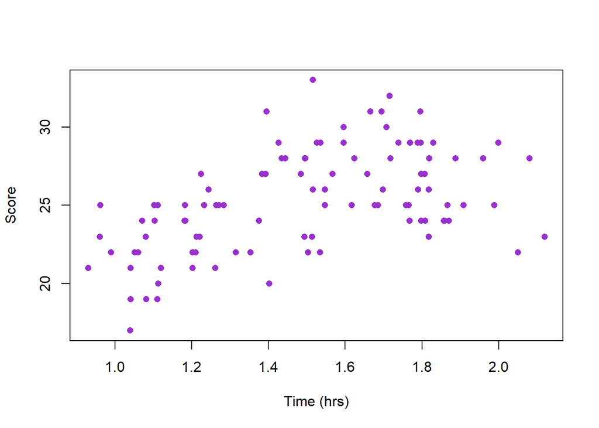

```r
# Create new variable
  times$hours_sq <- (times$hours)^2

# Regression model
  lm(score ~ hours + hours_sq,
     data = times)
```

```
##
## Call:
## lm(formula = score ~ hours + hours_sq, data = times)
##
## Coefficients:
## (Intercept)        hours     hours_sq
##      -7.974       40.853      -11.964
```

### Dummy Variables

Create dummy variables using the `ifelse` function.

*Code*: `dummy <- ifelse(variable = desired_value, 1, 0)`

*Example*:

The students in the pre- and post-test data set are either in 9th or 10th grade. Let’s make a dummy variable that indicates whether or not a student is in 9th grade. Then we’ll regress pre-test scores on the grade dummy.

```r
# Create dummy
  sg$ninth <- ifelse(sg$grade == 9, 1, 0)

# Regression model
  lm(pre ~ ninth,
     data = sg)
```

```
##
## Call:
## lm(formula = pre ~ ninth, data = sg)
##
## Coefficients:
## (Intercept)        ninth
##       22.42        -5.20
```

### Interactions

Just as with non-linear regressions we just need to create a new variable by finding the product of the two variables we want to interact.

*Example*:

Let’s interact pre-test score and grade level in a model predicting post-test scores.

```r
# Create new variable
  sg$pre_grade <- sg$pre * sg$grade

# Regression model
  int_reg <- lm(post ~ pre + grade + pre_grade,
                data = sg)
```

```
##
## Call:
## lm(formula = post ~ pre + grade + pre_grade, data = sg)
##
## Coefficients:
## (Intercept)          pre        grade    pre_grade
##     43.5124      -0.5479      -3.5224       0.1729
```

### Regression Values

If you have a regression object saved in your global environment, you can use it to call upon various values.

#### Coefficients

You can either get all of them, or only the one(s) you want. The variable name will print above the value. Notice in the examples that the full variable name `df$variable` shows for the `scores_reg` values because we used them in the regression definition. The `sg_reg` values only print the variable name because we used the `data` option.

1. All coefficients

*Code*: `reg$coefficients`

*Example*:

```r
scores_reg$coefficients
```

```
## (Intercept)      sg$pre
##   10.442504    1.086655
```

I’ll re-define the `scores_reg` object to only show the variable name, so we can make a regression output table

```r
scores_reg <- lm(post ~ pre,
                 data = sg)
```

2. Certain coefficients

Use an index to get only the values you want. The intercept is first, then the variable coefficients go in the order in which you wrote them in the model.

*Examples*:

```r
sg_reg$coefficients[1]
```

```
## (Intercept)
##    11.44528
```

```r
sg_reg$coefficients[2]
```

```
##      pre
## 1.104303
```

```r
sg_reg$coefficients[2:3]
```

```
##        pre      grade
##  1.1043030 -0.1423758
```

#### Fitted Values

You can get the predicted value of the y variable for each observation in the data used to create the regression model.

*Code*: `reg$fitted.values`

*Example*:

```r
sg$pred <- sg_reg$fitted.values
```

| pre | post | grade | pred |
| --- | --- | --- | --- |
| 19 | 31 | 9 | 31.15 |
| 19 | 28 | 9 | 31.15 |
| 24 | 33 | 10 | 36.52 |
| 21 | 29 | 10 | 33.21 |
| 19 | 30 | 9 | 31.15 |
| 16 | 30 | 9 | 27.83 |
| 23 | 33 | 10 | 35.42 |
| 22 | 33 | 10 | 34.32 |

#### Residuals

You can get the residual for each row of data used to create the regression model.

*Code*: `reg$residuals`

*Example*:

```r
sg$res <- sg_reg$residuals
```

| pre | post | grade | pred | res |
| --- | --- | --- | --- | --- |
| 19 | 31 | 9 | 31.15 | -0.1457 |
| 19 | 28 | 9 | 31.15 | -3.146 |
| 24 | 33 | 10 | 36.52 | -3.525 |
| 21 | 29 | 10 | 33.21 | -4.212 |
| 19 | 30 | 9 | 31.15 | -1.146 |
| 16 | 30 | 9 | 27.83 | 2.167 |
| 23 | 33 | 10 | 35.42 | -2.42 |
| 22 | 33 | 10 | 34.32 | -1.316 |

### Regression Statistics

If you type the regression object’s name into the console, you’ll see the formula and coefficients. Use the `summary` function to get more statistics from your regression model.

#### Quick View

Simply type `summary(reg)` into the console to see the basic regression stats, including:

- The regression equation
- Residual quartiles
- Coefficients with SE, T-value, and p-value, and significance stars
- RMSE
- R^2 & adjusted R^2
- F-Stat and p-value

*Example*:

```r
summary(sg_reg)
```

```
##
## Call:
## lm(formula = post ~ pre + grade, data = sg)
##
## Residuals:
##     Min      1Q  Median      3Q     Max
## -4.3162 -1.7545  0.1151  1.1635  6.2666
##
## Coefficients:
##             Estimate Std. Error t value Pr(>|t|)
## (Intercept)  11.4453     5.3276   2.148   0.0342 *
## pre           1.1043     0.1130   9.776 4.09e-16 ***
## grade        -0.1424     0.7316  -0.195   0.8461
## ---
## Signif. codes:  0 '***' 0.001 '**' 0.01 '*' 0.05 '.' 0.1 ' ' 1
##
## Residual standard error: 2.181 on 97 degrees of freedom
## Multiple R-squared:  0.7286, Adjusted R-squared:  0.723
## F-statistic: 130.2 on 2 and 97 DF,  p-value: < 2.2e-16
```

#### Calling On Regression Stat Values

You can save the regression summary as a new object and use its options to call upon the different values.

*Summary Object Code*: `reg_sum <- summary(reg)`

*Example*:

```r
sg_sum <- summary(sg_reg)
```

1. Coefficient Stats

The code `reg_sum$coefficients` will print a matrix of values with the coefficients, SE, t-value, and p-value for the intercept and each predictor variable.

*Example*:

```r
sg_sum$coefficients
```

```
##               Estimate Std. Error    t value     Pr(>|t|)
## (Intercept) 11.4452838  5.3276337  2.1482866 3.418122e-02
## pre          1.1043030  0.1129617  9.7759099 4.085808e-16
## grade       -0.1423758  0.7316428 -0.1945974 8.461151e-01
```

You can specify certain entries with an index.

*Examples*:

```r
# Get all values for the grade variable (third row)
  sg_sum$coefficients[3,]
```

```
##   Estimate Std. Error    t value   Pr(>|t|)
## -0.1423758  0.7316428 -0.1945974  0.8461151
```

```r
# Get all standard errors (second column)
  sg_sum$coefficients[,2]
```

```
## (Intercept)         pre       grade
##   5.3276337   0.1129617   0.7316428
```

```r
# Get the p-value for the pre-test scores variable (second row, fourth column)
  sg_sum$coefficients[2,4]
```

```
## [1] 4.085808e-16
```

2. RMSE

*Code*: `reg_sum$sigma`

*Example*:

Let’s get the RMSE for the *sg_reg* model.

```r
sg_sum$sigma
```

```
## [1] 2.18095
```

3. R^2

*Code*: `reg_sum$r.squared` OR `reg_sum$adj.r.squared`

*Examples*:

```r
# R^2
  sg_sum$r.squared
```

```
## [1] 0.7285909
```

```r
# Adjusted
  sg_sum$adj.r.squared
```

```
## [1] 0.7229948
```

4. F-Stat

Getting the F-test values is kind of weird with the summary object, so I actually like to use the `glance` function in the **broom** package.

*Note*: You can also get the R^2 values, and RMSE from the glance object if you’d like.

*Glance Object Code*: `glance_object <- broom::glance(reg)`

*Example*

```r
sg_f <- glance(sg_reg)
```

*F-Stat Code*: `glance_object$statistic`

*Example*:

```r
# Get F-stat
  sg_f$statistic
```

```
##   value
## 130.197
```

*F-Test p-Value Code*: `glance_object$p.value`

*Example*:

```r
# F-Stat p-Value
  sg_f$p.value
```

```
##        value
## 3.394591e-28
```

### Plotting Regression Lines

These are basic graphs. Please see the Visualizations in R file for more options.

#### Linear Regressions

As shown in the Visualizations in R file, use can use a regression object as the argument in the `abline` function. You need an existing plot to graph the line onto.

*Code*: `abline(reg_object)` or `abline(lm(y ~ x))`

*Example*

We have a set of raw test scores and the time it took each student to complete the test in the *times* data frame. We’ll make a scatter plot of these data points and plot the linear regression line on top.

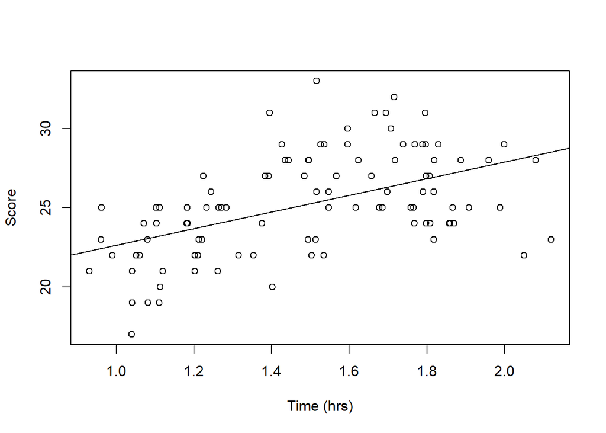

```r
# Scatter plot
  plot(times$hours,
       times$score,
       xlab = "Time (hrs)",
       ylab = "Score")

# Linear regression line
  abline(lm(score ~ hours,
            data = times))
```

#### Non-Linear Regressions

Use the following process to plot a non-linear regression:

1. Create a new variable that is the square/cube/log of your independent variable and run the regression (see the Non-Linear Regression section for details).
2. Find the predicted values for each observation
3. Arrange the data by the independent variable (you may want to do this in a copy of your data frame if you want to keep the original order)
4. Plot the points for the predicted values over the dependent variable using the `type = "l"` option

*Code*:

```
# 1. Make new variables and run the regression

# 2. Find predicted values
  df$pred <- reg$fitted.values

# 3. Arrange by the independent variable
  df <- arrange(df, indep_var)

# 4. Plot points as a line
  points(df$indep_var,
         df$pred,
         type = "l")
```

*Example*:

We can see a noticable dip in the scores at the end of the time range, which indicates that this data may be nonlinear. We will try a quadratic regression instead.

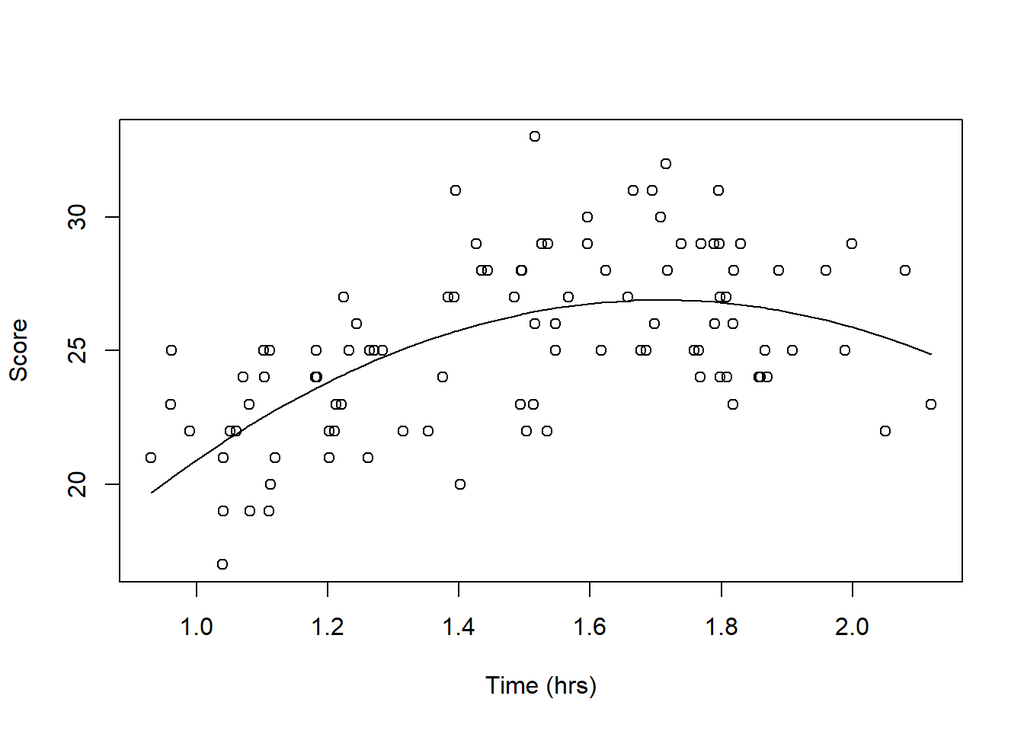

```r
# Scatter plot
  plot(times$hours,
       times$score,
       xlab = "Time (hrs)",
       ylab = "Score")

# 1. Create new variable & run regression
  times$hours_sq <- (times$hours)^2

  times_reg <- lm(score ~ hours + hours_sq,
                  data = times)

# 2. Find predicted values
  times$pred <- times_reg$fitted.values

# 3. Arrange by the independent variable (I'll make a copy)
  times_ordered <- plyr::arrange(times, hours)

# 4. Plot points as a line
  points(times_ordered$hours,
         times_ordered$pred,
         type = "l")
```

### Regression Tables

There’s a package that prints regression output tables as text files, but these can be hard to format in your document. Below, I’ll show the code and output for that package. I’ll also share a function I wrote to create a data frame that you can save as a csv file and copy into Word, which will let you adjust the formatting more easily.

#### Stargazer

Use the `stargazer` function in the **stargazer** package to make quick regression tables. You need to specify what type of output you want using the `type` option. If you want to be able to read it in the console or export it as text, you’ll want to use `type = "text"`. You can also use the `"latex"` or `"html"` options if your documents are in those formats.

*Code*:

```
stargazer::stargazer(reg1,
                     reg2,
                     ...,
                     type = "format")
```

*Example*:

Let’s make a regression output table with the scores regression, the scores & grade level regression, and the regression with interactions.

```r
stargazer(scores_reg,
          sg_reg,
          int_reg,
          type = "text")
```

```
##
## ==========================================================================================
##                                              Dependent variable:
##                     ----------------------------------------------------------------------
##                                                      post
##                               (1)                     (2)                    (3)
## ------------------------------------------------------------------------------------------
## pre                        1.087***                1.104***                 -0.548
##                             (0.067)                 (0.113)                (2.178)
##
## grade                                               -0.142                  -3.522
##                                                     (0.732)                (4.510)
##
## pre_grade                                                                   0.173
##                                                                            (0.228)
##
## Constant                   10.443***               11.445**                 43.512
##                             (1.346)                 (5.328)                (42.557)
##
## ------------------------------------------------------------------------------------------
## Observations                  100                     100                    100
## R2                           0.728                   0.729                  0.730
## Adjusted R2                  0.726                   0.723                  0.722
## Residual Std. Error     2.170 (df = 98)         2.181 (df = 97)        2.186 (df = 96)
## F Statistic         262.938*** (df = 1; 98) 130.197*** (df = 2; 97) 86.612*** (df = 3; 96)
## ==========================================================================================
## Note:                                                          *p<0.1; **p<0.05; ***p<0.01
```

There are some options that you can use to change values and export your table:

1. Title

Make a title for your table using the `title` option.

*Example*:

```r
stargazer(scores_reg,
          sg_reg,
          int_reg,
          type = "text",
          title = "Post-Test Score Regressions with Pre-Test Score and Grade Level Predictors")
```

```
##
## Post-Test Score Regressions with Pre-Test Score and Grade Level Predictors
## ==========================================================================================
##                                              Dependent variable:
##                     ----------------------------------------------------------------------
##                                                      post
##                               (1)                     (2)                    (3)
## ------------------------------------------------------------------------------------------
## pre                        1.087***                1.104***                 -0.548
##                             (0.067)                 (0.113)                (2.178)
##
## grade                                               -0.142                  -3.522
##                                                     (0.732)                (4.510)
##
## pre_grade                                                                   0.173
##                                                                            (0.228)
##
## Constant                   10.443***               11.445**                 43.512
##                             (1.346)                 (5.328)                (42.557)
##
## ------------------------------------------------------------------------------------------
## Observations                  100                     100                    100
## R2                           0.728                   0.729                  0.730
## Adjusted R2                  0.726                   0.723                  0.722
## Residual Std. Error     2.170 (df = 98)         2.181 (df = 97)        2.186 (df = 96)
## F Statistic         262.938*** (df = 1; 98) 130.197*** (df = 2; 97) 86.612*** (df = 3; 96)
## ==========================================================================================
## Note:                                                          *p<0.1; **p<0.05; ***p<0.01
```

2. Column Lables

You can label your regression models using the `column.labels` option.

```r
stargazer(scores_reg,
          sg_reg,
          int_reg,
          type = "text",
          column.labels = c("Scores", "Scores & Grade", "Interactions"))
```

```
##
## ==========================================================================================
##                                              Dependent variable:
##                     ----------------------------------------------------------------------
##                                                      post
##                             Scores                  Scores                  Grade
##                               (1)                     (2)                    (3)
## ------------------------------------------------------------------------------------------
## pre                        1.087***                1.104***                 -0.548
##                             (0.067)                 (0.113)                (2.178)
##
## grade                                               -0.142                  -3.522
##                                                     (0.732)                (4.510)
##
## pre_grade                                                                   0.173
##                                                                            (0.228)
##
## Constant                   10.443***               11.445**                 43.512
##                             (1.346)                 (5.328)                (42.557)
##
## ------------------------------------------------------------------------------------------
## Observations                  100                     100                    100
## R2                           0.728                   0.729                  0.730
## Adjusted R2                  0.726                   0.723                  0.722
## Residual Std. Error     2.170 (df = 98)         2.181 (df = 97)        2.186 (df = 96)
## F Statistic         262.938*** (df = 1; 98) 130.197*** (df = 2; 97) 86.612*** (df = 3; 96)
## ==========================================================================================
## Note:                                                          *p<0.1; **p<0.05; ***p<0.01
```

3. Dependent Variable Label

Use the `dep.val.labels` option to change the name of the y variable.

```r
stargazer(scores_reg,
          sg_reg,
          int_reg,
          type = "text",
          dep.var.labels = "Post-Test Scores")
```

```
##
## ==========================================================================================
##                                              Dependent variable:
##                     ----------------------------------------------------------------------
##                                                Post-Test Scores
##                               (1)                     (2)                    (3)
## ------------------------------------------------------------------------------------------
## pre                        1.087***                1.104***                 -0.548
##                             (0.067)                 (0.113)                (2.178)
##
## grade                                               -0.142                  -3.522
##                                                     (0.732)                (4.510)
##
## pre_grade                                                                   0.173
##                                                                            (0.228)
##
## Constant                   10.443***               11.445**                 43.512
##                             (1.346)                 (5.328)                (42.557)
##
## ------------------------------------------------------------------------------------------
## Observations                  100                     100                    100
## R2                           0.728                   0.729                  0.730
## Adjusted R2                  0.726                   0.723                  0.722
## Residual Std. Error     2.170 (df = 98)         2.181 (df = 97)        2.186 (df = 96)
## F Statistic         262.938*** (df = 1; 98) 130.197*** (df = 2; 97) 86.612*** (df = 3; 96)
## ==========================================================================================
## Note:                                                          *p<0.1; **p<0.05; ***p<0.01
```

4. Predictor Variable Labels

Rename your predictor variables using the `covariate.labels` option.

```r
stargazer(scores_reg,
          sg_reg,
          int_reg,
          type = "text",
          covariate.labels = c("Pre-Test Scores", "Grade Level", "Interaction"))
```

```
##
## ==========================================================================================
##                                              Dependent variable:
##                     ----------------------------------------------------------------------
##                                                      post
##                               (1)                     (2)                    (3)
## ------------------------------------------------------------------------------------------
## Pre-Test Scores            1.087***                1.104***                 -0.548
##                             (0.067)                 (0.113)                (2.178)
##
## Grade Level                                         -0.142                  -3.522
##                                                     (0.732)                (4.510)
##
## Interaction                                                                 0.173
##                                                                            (0.228)
##
## Constant                   10.443***               11.445**                 43.512
##                             (1.346)                 (5.328)                (42.557)
##
## ------------------------------------------------------------------------------------------
## Observations                  100                     100                    100
## R2                           0.728                   0.729                  0.730
## Adjusted R2                  0.726                   0.723                  0.722
## Residual Std. Error     2.170 (df = 98)         2.181 (df = 97)        2.186 (df = 96)
## F Statistic         262.938*** (df = 1; 98) 130.197*** (df = 2; 97) 86.612*** (df = 3; 96)
## ==========================================================================================
## Note:                                                          *p<0.1; **p<0.05; ***p<0.01
```

5. Export Table

Use the `out` option to save the table as either a .tex, .txt, .htm, or .html file.

```r
stargazer(scores_reg,
          sg_reg,
          int_reg,
          type = "text",
          dep.var.labels = "Post-Test Scores",
          covariate.labels = c("Pre-Test Scores", "Grade Level", "Interaction"),
          out = paste(tf_dir, "Regression Output.txt", sep = ""))
```

```
##
## ==========================================================================================
##                                              Dependent variable:
##                     ----------------------------------------------------------------------
##                                                Post-Test Scores
##                               (1)                     (2)                    (3)
## ------------------------------------------------------------------------------------------
## Pre-Test Scores            1.087***                1.104***                 -0.548
##                             (0.067)                 (0.113)                (2.178)
##
## Grade Level                                         -0.142                  -3.522
##                                                     (0.732)                (4.510)
##
## Interaction                                                                 0.173
##                                                                            (0.228)
##
## Constant                   10.443***               11.445**                 43.512
##                             (1.346)                 (5.328)                (42.557)
##
## ------------------------------------------------------------------------------------------
## Observations                  100                     100                    100
## R2                           0.728                   0.729                  0.730
## Adjusted R2                  0.726                   0.723                  0.722
## Residual Std. Error     2.170 (df = 98)         2.181 (df = 97)        2.186 (df = 96)
## F Statistic         262.938*** (df = 1; 98) 130.197*** (df = 2; 97) 86.612*** (df = 3; 96)
## ==========================================================================================
## Note:                                                          *p<0.1; **p<0.05; ***p<0.01
```

#### Data Frame Function

You can use this function for whatever combination of regressons you want. Just enter a vector of regression object names (as characters) and a vector of variable names in the order in which you’d like them to appear in your table. You can add or remove rows, just make sure you adjust the row indeces accordingly. You may get a warning sometimes if you have a factor vector, but it will just make it a character to use the *full_join* function.

For best results, use the `data` option when you define your regressions. You may also want to change the names of the columns and rows either by using the `names` and `row.names` functions or just changing them when you export the table.

Note that it looks weird printed here because the files R makes are spaced very widely. When you make it a table in word, it’ll look much better.

**Note**: You need to have the **dplyr** and **broom** packages loaded for the function to work properly.

```r
reg_table <- function(reg_list, var_vector) {
  # Start table
    table <- data.frame(value = as.character(c(var_vector,
                                               "Constant",
                                               "Observations",
                                               "R^2",
                                               "Adj. R^2",
                                               "RMSE",
                                               "F-Stat")))

  # Values
    for (i in 1:length(reg_list)) {
      reg <- eval(parse(text = reg_list[i]))
      reg_name <- reg_list[i]
      reg_sum <- summary(reg)
      var_names <- as.vector(names(reg_sum$aliased[which(reg_sum$aliased == FALSE)])[-1])
      var_num <- length(var_names)

      temp <- data.frame(value = as.character(c(var_names,
                                                "Constant",
                                                "Observations",
                                                "R^2",
                                                "Adj. R^2",
                                                "RMSE",
                                                "F-Stat")))

      temp[[reg_name]] <- rep(NA, nrow(temp))

      # Get coefficients
        for (j in 1:var_num) {
          if (reg_sum$coefficients[j+1, 4] < 0.05 & reg_sum$coefficients[j+1, 4] >= 0.01) {
            stars <- "*"
          } else if (reg_sum$coefficients[j+1, 4] < 0.01) {
            stars <- "**"
          } else if (reg_sum$coefficients[j+1, 4] < 0.001) {
            stars <- "***"
          } else {
            stars <- ""
          }

          temp[[reg_name]][j] <- paste(round(reg_sum$coefficients[j+1, 1], 2),
                                       stars,
                                       " (",
                                       round(reg_sum$coefficients[j+1, 2], 2),
                                       ")",
                                       sep = "")
        }



      # Intercept
        if (reg_sum$coefficients[1, 4] < 0.05 & reg_sum$coefficients[1, 4] >= 0.01) {
          stars <- "*"
        } else if (reg_sum$coefficients[1, 4] < 0.01) {
          stars <- "**"
        } else if (reg_sum$coefficients[1, 4] < 0.001) {
          stars <- "***"
        } else {
          stars <- ""
        }

        temp[[reg_name]][var_num + 1] <- paste(round(reg_sum$coefficients[1, 1], 2),
                                                stars,
                                                " (",
                                                round(reg_sum$coefficients[1, 2], 2),
                                                ")",
                                                sep = "")


      # Observations
        temp[[reg_name]][var_num + 2] <- nobs(reg)

      # R^2
        temp[[reg_name]][var_num + 3] <- round(reg_sum$r.squared, 3)

      # Adjusted R^2
        temp[[reg_name]][var_num + 4] <- round(reg_sum$adj.r.squared, 3)

      # RMSE
        temp[[reg_name]][var_num + 5] <- paste(round(reg_sum$sigma, 2),
                                               " (df = ",
                                               reg_sum$df[2],
                                               ")",
                                               sep = "")

      # F-Stat
        ftest <- glance(reg)
        if (ftest$p.value < 0.05 & ftest$p.value >= 0.01) {
          stars <- "**"
        } else if (ftest$p.value < 0.01) {
          stars <- "***"
        } else {
          stars <- ""
        }

        temp[[reg_name]][var_num + 6] <- paste(round(ftest$statistic, 1),
                                               stars,
                                               " (df = ",
                                               ftest$df,
                                               "; ",
                                               reg_sum$df[2],
                                               ")",
                                               sep = "")

      # Bind to table
        table <- full_join(by = "value",
                           table,
                           temp)

  }

  # Get rid of NA's
    for (i in reg_list) {
      table[[i]] <- ifelse(is.na(table[[i]]), "", table[[i]])
    }

  # Make values column the row names
    row.names(table) <- table$value
    table$value <- NULL

  return(table)
}
```

*Example*:

Let’s make a regression output table for the scores, scores and grade, and interactions models.

```r
reg_output <- reg_table(c("scores_reg", "sg_reg", "int_reg"), # List of regresion object names as strings
                        c("pre", "grade", "pre_grade")) # list of variable names in the order I want them
```

Table continues below

|  | scores_reg | sg_reg |
| --- | --- | --- |
| **pre** | 1.09** (0.07) | 1.1** (0.11) |
| **grade** |  | -0.14 (0.73) |
| **pre_grade** |  |  |
| **Constant** | 10.44** (1.35) | 11.45* (5.33) |
| **Observations** | 100 | 100 |
| **R^2** | 0.728 | 0.729 |
| **Adj. R^2** | 0.726 | 0.723 |
| **RMSE** | 2.17 (df = 98) | 2.18 (df = 97) |
| **F-Stat** | 262.9*** (df = 1; 98) | 130.2*** (df = 2; 97) |

|  | int_reg |
| --- | --- |
| **pre** | -0.55 (2.18) |
| **grade** | -3.52 (4.51) |
| **pre_grade** | 0.17 (0.23) |
| **Constant** | 43.51 (42.56) |
| **Observations** | 100 |
| **R^2** | 0.73 |
| **Adj. R^2** | 0.722 |
| **RMSE** | 2.19 (df = 96) |
| **F-Stat** | 86.6*** (df = 3; 96) |

I’ll save a copy of the regression table as a csv to the GitHub folder, so you can see what it looks like.

```r
write.csv(reg_output, paste(tf_dir, "Regression Table.csv", sep = ""))
```

## Classical

You can use the `alpha` function in the **psych** package to get the basic classical statistics. Save the alpha output as an object to call upon certain values

*Code*: `alpha_obj <- psych::alpha(df)`

### Quick View

Just type in `alpha(df)` to get a print-out of all of the stats.

*Code*: `psych::alpha(df)`

*Example*:

Let’s get the classical stats for the *test* data frame.

```r
alpha(test)
```

```
##
## Reliability analysis
## Call: alpha(x = test)
##
##   raw_alpha std.alpha G6(smc) average_r S/N    ase mean   sd median_r
##       0.82      0.82    0.82      0.19 4.5 0.0083 0.48 0.22     0.19
##
##  lower alpha upper     95% confidence boundaries
## 0.8 0.82 0.83
##
##  Reliability if an item is dropped:
##     raw_alpha std.alpha G6(smc) average_r S/N alpha se  var.r med.r
## q1       0.82      0.82    0.82      0.19 4.5   0.0084 0.0045  0.20
## q2       0.82      0.82    0.82      0.19 4.6   0.0083 0.0040  0.20
## q3       0.82      0.82    0.82      0.19 4.6   0.0082 0.0042  0.20
## q4       0.82      0.82    0.82      0.19 4.6   0.0082 0.0040  0.20
## q5       0.82      0.82    0.82      0.19 4.5   0.0084 0.0045  0.20
## q6       0.81      0.81    0.81      0.18 4.3   0.0087 0.0047  0.19
## q7       0.81      0.81    0.81      0.18 4.2   0.0088 0.0045  0.19
## q8       0.81      0.81    0.81      0.19 4.3   0.0086 0.0047  0.19
## q9       0.81      0.81    0.81      0.18 4.2   0.0088 0.0046  0.19
## q10      0.81      0.81    0.81      0.19 4.3   0.0086 0.0046  0.19
## q11      0.81      0.81    0.81      0.18 4.3   0.0087 0.0047  0.19
## q12      0.81      0.81    0.81      0.18 4.2   0.0088 0.0045  0.19
## q13      0.81      0.81    0.81      0.18 4.2   0.0088 0.0044  0.18
## q14      0.80      0.81    0.80      0.18 4.1   0.0090 0.0041  0.18
## q15      0.80      0.81    0.80      0.18 4.2   0.0089 0.0043  0.18
## q16      0.81      0.81    0.81      0.18 4.3   0.0087 0.0047  0.19
## q17      0.81      0.81    0.81      0.18 4.2   0.0088 0.0044  0.19
## q18      0.81      0.81    0.81      0.18 4.2   0.0088 0.0046  0.19
## q19      0.81      0.81    0.81      0.18 4.3   0.0087 0.0045  0.19
## q20      0.81      0.81    0.81      0.18 4.3   0.0087 0.0048  0.19
##
##  Item statistics
##        n raw.r std.r r.cor r.drop mean   sd
## q1  1000  0.37  0.37  0.31   0.27 0.69 0.46
## q2  1000  0.33  0.33  0.26   0.23 0.52 0.50
## q3  1000  0.33  0.33  0.25   0.23 0.45 0.50
## q4  1000  0.31  0.31  0.24   0.21 0.62 0.48
## q5  1000  0.39  0.38  0.32   0.29 0.52 0.50
```

[output cut: 23 more lines]

```
## q6  0.76 0.24    0
## q7  0.62 0.38    0
## q8  0.32 0.68    0
## q9  0.54 0.46    0
## q10 0.80 0.20    0
## q11 0.66 0.34    0
## q12 0.58 0.42    0
## q13 0.64 0.36    0
## q14 0.47 0.53    0
## q15 0.35 0.65    0
## q16 0.77 0.23    0
## q17 0.70 0.30    0
## q18 0.37 0.63    0
## q19 0.44 0.56    0
## q20 0.26 0.74    0
```

### Alpha

Use the `raw_alpha` value in the `total` sublist to get the alpha value from your object.

*Code*: `alpha_obj$total$raw_alpha`

*Example*:

```r
# save alpha object
  test_alpha <- alpha(test)

# Get raw alpha
  test_alpha$total$raw_alpha
```

```
## [1] 0.8182738
```

### Difficulty

The difficulty statistic is just the proportion of respondents who answered each item correctly. We can get this by taking the second column of the `response.freq` option in our alpha object.

*Code*: `alpha_obj$response.freq[,2]`

```r
test_alpha$response.freq[,2]
```

```
##    q1    q2    q3    q4    q5    q6    q7    q8    q9   q10   q11   q12   q13
## 0.686 0.525 0.446 0.625 0.524 0.244 0.380 0.681 0.458 0.205 0.337 0.423 0.358
##   q14   q15   q16   q17   q18   q19   q20
## 0.533 0.647 0.232 0.299 0.630 0.556 0.743
```

### Discrimination

You usually want to get the discrimination values calculated by dropping the item. Get these using the `r.drop` option in the `item.stats` sublist.

*Code*: `alpha_obj$item.stats$r.drop`

*Example*:

```r
test_alpha$item.stats$r.drop
```

```
##  [1] 0.2741841 0.2278590 0.2271503 0.2129523 0.2851947 0.4010077 0.4367561
##  [8] 0.3884747 0.4369975 0.3876920 0.3948824 0.4546102 0.4718230 0.5087129
## [15] 0.4976428 0.4094857 0.4708636 0.4352272 0.4308398 0.4125565
```

### Factor Analysis

#### Scree Plots

To make a scree plot use the `fa.parallel` function in the **psych** package. You can also save the object to pull out values, if you want. Use `?fa.parallel` to see all of the options for factor method and factor types.

*Code*:

```
fa.parallel(df,
            fm = "factor method option",
            fa = "component or factor option",
            n.inter = number_of_simulations,
            SMC = TRUE or FALSE (tells when to find eigenvalues, see help file),
            ylabel = "Label",
            show.legend = FALSE (their legend is gross, make your own))
```

*Example*:

Let’s make a scree plot for the items in the *test* data frame.

```r
  fa.parallel(test,
              fm = "pa",
              fa = "fa",
              n.iter = 50,
              SMC = TRUE,
              ylabel = "Eigenvalues of Factors",
              show.legend = FALSE)
```

```
## Parallel analysis suggests that the number of factors =  1  and the number of components =  NA
```

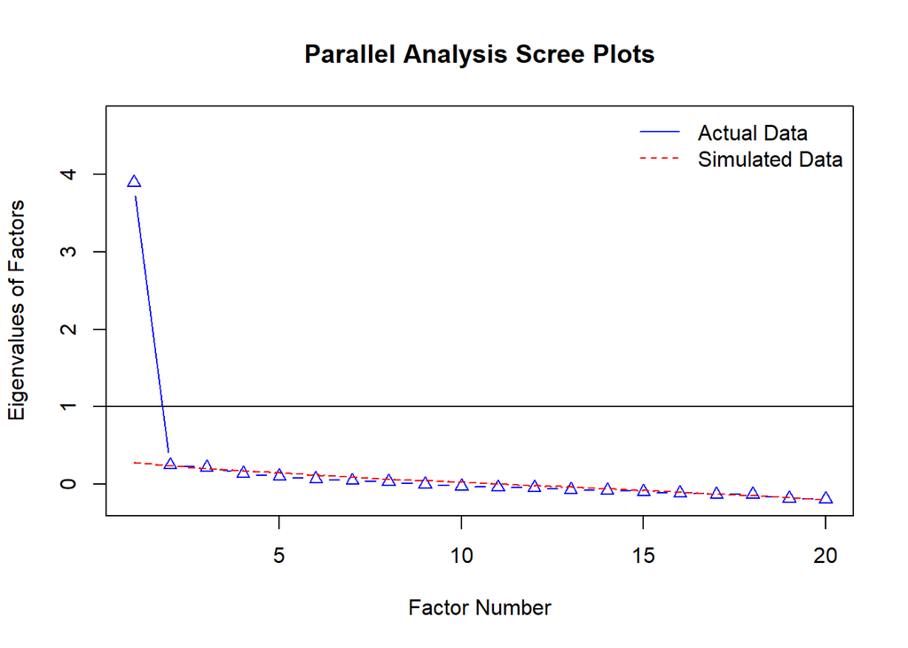

```r
  legend("topright",
         bty = "n",
         legend = c("Actual Data", "Simulated Data"),
         lty = c(1, 2),
         col = c("blue", "red"))
```

#### EFA Loadings Table

Use the `fa` function in the **psych** package to create a factor loadings table that you can export and copy into a document. See the help file `?fa` for more details on options.

*Basic Code*:

```
ela_obj <- fa(df,
              nfactors = number,
              rotate = "rotation method",
              scores = "score option",
              fm = "factor method")
```

*Example*:

Let’s print a table of the factor loadings for each item in the *test* data frame.

```r
efa<-fa(test,
        nfactors=2,
        rotate="promax",
        scores="regression",
        residuals=FALSE,
        SMC=TRUE,
        covar=FALSE,
        missing=FALSE,
        impute="median",
        min.err = 0.001,
        max.iter = 50,
        symmetric=TRUE,
        warnings=TRUE,
        fm="pa",
        use="pairwise",
        cor="cor")

print(efa$loadings,cut=.3)
```

```
##
## Loadings:
##     PA1    PA2
## q1
## q2          0.695
## q3
## q4
## q5   0.430
## q6   0.444
## q7   0.433
## q8   0.360
## q9   0.309
## q10  0.356
## q11  0.400
## q12  0.513
## q13  0.555
## q14         0.364
## q15  0.441
## q16  0.391
## q17  0.402
## q18  0.484
## q19  0.516
## q20  0.306
##
##                  PA1   PA2
## SS loadings    3.102 0.845
## Proportion Var 0.155 0.042
## Cumulative Var 0.155 0.197
```

### Interitem Correlations

You can use the `cor` function with an entire numerical data frame as the argument, and it will find the correlations between each of the variables. You can round off all of the values by placing the `cor` command as the argument in `round`

*Code*: `cor(df)`

*Example*:

Let’s make a correlation matrix for our *test* data frame.

```r
  cor_table <- round(cor(test), 2)
```

Table continues below

|  | q1 | q2 | q3 | q4 | q5 | q6 | q7 | q8 | q9 | q10 |
| --- | --- | --- | --- | --- | --- | --- | --- | --- | --- | --- |
| **q1** | 1 | 0.12 | 0.07 | 0.1 | 0.04 | 0.13 | 0.14 | 0.17 | 0.13 | 0.1 |
| **q2** | 0.12 | 1 | 0.05 | 0.03 | 0.01 | 0.1 | 0.12 | 0.11 | 0.18 | 0.13 |
| **q3** | 0.07 | 0.05 | 1 | 0.08 | 0.13 | 0.12 | 0.1 | 0.11 | 0.17 | 0.11 |
| **q4** | 0.1 | 0.03 | 0.08 | 1 | 0.11 | 0.1 | 0.09 | 0.09 | 0.09 | 0.04 |
| **q5** | 0.04 | 0.01 | 0.13 | 0.11 | 1 | 0.16 | 0.16 | 0.16 | 0.14 | 0.16 |
| **q6** | 0.13 | 0.1 | 0.12 | 0.1 | 0.16 | 1 | 0.23 | 0.19 | 0.18 | 0.22 |
| **q7** | 0.14 | 0.12 | 0.1 | 0.09 | 0.16 | 0.23 | 1 | 0.15 | 0.26 | 0.24 |
| **q8** | 0.17 | 0.11 | 0.11 | 0.09 | 0.16 | 0.19 | 0.15 | 1 | 0.18 | 0.15 |
| **q9** | 0.13 | 0.18 | 0.17 | 0.09 | 0.14 | 0.18 | 0.26 | 0.18 | 1 | 0.23 |
| **q10** | 0.1 | 0.13 | 0.11 | 0.04 | 0.16 | 0.22 | 0.24 | 0.15 | 0.23 | 1 |
| **q11** | 0.13 | 0.1 | 0.11 | 0.08 | 0.15 | 0.2 | 0.22 | 0.21 | 0.21 | 0.2 |
| **q12** | 0.15 | 0.11 | 0.12 | 0.12 | 0.19 | 0.23 | 0.27 | 0.18 | 0.25 | 0.24 |
| **q13** | 0.16 | 0.1 | 0.14 | 0.14 | 0.19 | 0.21 | 0.27 | 0.23 | 0.26 | 0.24 |
| **q14** | 0.15 | 0.25 | 0.09 | 0.11 | 0.17 | 0.23 | 0.25 | 0.28 | 0.31 | 0.22 |
| **q15** | 0.19 | 0.13 | 0.11 | 0.15 | 0.18 | 0.24 | 0.28 | 0.26 | 0.27 | 0.21 |
| **q16** | 0.15 | 0.13 | 0.11 | 0.11 | 0.12 | 0.23 | 0.26 | 0.18 | 0.2 | 0.21 |
| **q17** | 0.11 | 0.17 | 0.13 | 0.11 | 0.17 | 0.25 | 0.25 | 0.2 | 0.25 | 0.25 |
| **q18** | 0.16 | 0.08 | 0.14 | 0.15 | 0.11 | 0.2 | 0.25 | 0.24 | 0.23 | 0.18 |
| **q19** | 0.12 | 0.07 | 0.12 | 0.12 | 0.14 | 0.25 | 0.19 | 0.22 | 0.19 | 0.17 |
| **q20** | 0.22 | 0.16 | 0.1 | 0.17 | 0.15 | 0.15 | 0.22 | 0.22 | 0.2 | 0.21 |

|  | q11 | q12 | q13 | q14 | q15 | q16 | q17 | q18 | q19 | q20 |
| --- | --- | --- | --- | --- | --- | --- | --- | --- | --- | --- |
| **q1** | 0.13 | 0.15 | 0.16 | 0.15 | 0.19 | 0.15 | 0.11 | 0.16 | 0.12 | 0.22 |
| **q2** | 0.1 | 0.11 | 0.1 | 0.25 | 0.13 | 0.13 | 0.17 | 0.08 | 0.07 | 0.16 |
| **q3** | 0.11 | 0.12 | 0.14 | 0.09 | 0.11 | 0.11 | 0.13 | 0.14 | 0.12 | 0.1 |
| **q4** | 0.08 | 0.12 | 0.14 | 0.11 | 0.15 | 0.11 | 0.11 | 0.15 | 0.12 | 0.17 |
| **q5** | 0.15 | 0.19 | 0.19 | 0.17 | 0.18 | 0.12 | 0.17 | 0.11 | 0.14 | 0.15 |
| **q6** | 0.2 | 0.23 | 0.21 | 0.23 | 0.24 | 0.23 | 0.25 | 0.2 | 0.25 | 0.15 |
| **q7** | 0.22 | 0.27 | 0.27 | 0.25 | 0.28 | 0.26 | 0.25 | 0.25 | 0.19 | 0.22 |
| **q8** | 0.21 | 0.18 | 0.23 | 0.28 | 0.26 | 0.18 | 0.2 | 0.24 | 0.22 | 0.22 |
| **q9** | 0.21 | 0.25 | 0.26 | 0.31 | 0.27 | 0.2 | 0.25 | 0.23 | 0.19 | 0.2 |
| **q10** | 0.2 | 0.24 | 0.24 | 0.22 | 0.21 | 0.21 | 0.25 | 0.18 | 0.17 | 0.21 |
| **q11** | 1 | 0.23 | 0.22 | 0.24 | 0.24 | 0.19 | 0.26 | 0.22 | 0.2 | 0.19 |
| **q12** | 0.23 | 1 | 0.31 | 0.24 | 0.26 | 0.24 | 0.26 | 0.23 | 0.25 | 0.23 |
| **q13** | 0.22 | 0.31 | 1 | 0.28 | 0.26 | 0.21 | 0.27 | 0.29 | 0.27 | 0.21 |
| **q14** | 0.24 | 0.24 | 0.28 | 1 | 0.34 | 0.23 | 0.33 | 0.29 | 0.3 | 0.25 |
| **q15** | 0.24 | 0.26 | 0.26 | 0.34 | 1 | 0.25 | 0.3 | 0.26 | 0.26 | 0.28 |
| **q16** | 0.19 | 0.24 | 0.21 | 0.23 | 0.25 | 1 | 0.25 | 0.2 | 0.28 | 0.16 |
| **q17** | 0.26 | 0.26 | 0.27 | 0.33 | 0.3 | 0.25 | 1 | 0.21 | 0.27 | 0.2 |
| **q18** | 0.22 | 0.23 | 0.29 | 0.29 | 0.26 | 0.2 | 0.21 | 1 | 0.27 | 0.21 |
| **q19** | 0.2 | 0.25 | 0.27 | 0.3 | 0.26 | 0.28 | 0.27 | 0.27 | 1 | 0.21 |
| **q20** | 0.19 | 0.23 | 0.21 | 0.25 | 0.28 | 0.16 | 0.2 | 0.21 | 0.21 | 1 |

## IRT

There are two good packages for IRT in R: **eRm** and **mirt**.

**eRm** only uses the Rasch model and its extensions, and **mirt** can also do the 2PL and 3PL models and their extensions.

If you’re going to use the Rasch model only, I would recommend just using the shiny app, which uses the **eRm** package. You just upload your cleaned survey responses data file, and everything you need will show up in the different tabs of the app. You can download any of the tables and screenshot the images for your paper.

If you want to use a different theta estimation method (eRm uses the CML method) or a more complex model, you’ll want to use the **mirt** package.

The tabs below use the **mirt** package.

### Parameter Estimation

You can estimate theta values and item difficulties, discriminations, and guessing parameters using different IRT methods with **mirt**.

#### Item Parameter Estimation

Use the *mirt* function in the **mirt** package to generate model parameters. You can then use the *coef* function to extract the coefficients and SEs for your model.

Note that this will give you all four coefficients, even if you’re using a simpler model. You can just take the ones you’re actually using.

1. Make a basic item parameter table

You can use the `simplify` option to get just the item parameters.

*Code*:

```
# Run the model
  model <- mirt(data,
                factor_number,
                itemtype = "model option")

# Pull out coefficients
  model_coef <- coef(model,
                     IRTpars = TRUE,
                     simplify = TRUE)

# Create data frame (you can assign `NULL` to any unused coefficients.
  item_params <- data.frame(unlist(model_coef$items)
```

*Example*:

Let’s use the Rasch model to get item difficulty estimates for *test*.

```r
# Run the model
  rasch_mod <- mirt(test,
                    1,
                    itemtype = "Rasch")
```

```
##
Iteration: 1, Log-Lik: -11613.435, Max-Change: 0.11974
Iteration: 2, Log-Lik: -11608.258, Max-Change: 0.06426
Iteration: 3, Log-Lik: -11606.936, Max-Change: 0.03353
Iteration: 4, Log-Lik: -11606.607, Max-Change: 0.01701
Iteration: 5, Log-Lik: -11606.529, Max-Change: 0.00825
Iteration: 6, Log-Lik: -11606.511, Max-Change: 0.00404
Iteration: 7, Log-Lik: -11606.506, Max-Change: 0.00196
Iteration: 8, Log-Lik: -11606.505, Max-Change: 0.00097
Iteration: 9, Log-Lik: -11606.505, Max-Change: 0.00048
Iteration: 10, Log-Lik: -11606.505, Max-Change: 0.00022
Iteration: 11, Log-Lik: -11606.505, Max-Change: 0.00011
Iteration: 12, Log-Lik: -11606.505, Max-Change: 0.00006
```

```r
# Pull out coefficients
  rasch_coef <- coef(rasch_mod,
                     IRTpars = TRUE,
                     simplify = TRUE)

# Create data frame
  rasch_params <- data.frame(unlist(rasch_coef$items))
```

|  | a | b | g | u |
| --- | --- | --- | --- | --- |
| **q1** | 1 | -0.9764 | 0 | 1 |
| **q2** | 1 | -0.1296 | 0 | 1 |
| **q3** | 1 | 0.2674 | 0 | 1 |
| **q4** | 1 | -0.6421 | 0 | 1 |
| **q5** | 1 | -0.1246 | 0 | 1 |
| **q6** | 1 | 1.398 | 0 | 1 |
| **q7** | 1 | 0.608 | 0 | 1 |
| **q8** | 1 | -0.948 | 0 | 1 |
| **q9** | 1 | 0.2067 | 0 | 1 |
| **q10** | 1 | 1.668 | 0 | 1 |
| **q11** | 1 | 0.8405 | 0 | 1 |
| **q12** | 1 | 0.3845 | 0 | 1 |
| **q13** | 1 | 0.7256 | 0 | 1 |
| **q14** | 1 | -0.1698 | 0 | 1 |
| **q15** | 1 | -0.7599 | 0 | 1 |
| **q16** | 1 | 1.478 | 0 | 1 |
| **q17** | 1 | 1.057 | 0 | 1 |
| **q18** | 1 | -0.6687 | 0 | 1 |
| **q19** | 1 | -0.2859 | 0 | 1 |
| **q20** | 1 | -1.318 | 0 | 1 |

```r
# Get rid of values you aren't using
  rasch_params$a <- NULL
  rasch_params$g <- NULL
  rasch_params$u <- NULL
```

|  | b |
| --- | --- |
| **q1** | -0.9764 |
| **q2** | -0.1296 |
| **q3** | 0.2674 |
| **q4** | -0.6421 |
| **q5** | -0.1246 |
| **q6** | 1.398 |
| **q7** | 0.608 |
| **q8** | -0.948 |
| **q9** | 0.2067 |
| **q10** | 1.668 |
| **q11** | 0.8405 |
| **q12** | 0.3845 |
| **q13** | 0.7256 |
| **q14** | -0.1698 |
| **q15** | -0.7599 |
| **q16** | 1.478 |
| **q17** | 1.057 |
| **q18** | -0.6687 |
| **q19** | -0.2859 |
| **q20** | -1.318 |

2. Getting SEs for your coefficients

This time, we won’t simplify and will use the `SE = TRUE` option in the `mirt` function and the `printSE = TRUE` option in the `coef` function, so we can estract the SE values.

We’ll then make a blank data frame and fill it in with the values that we extract from the coef object.

Use the following column indeces for the different parameters:

- Column 1 for a
- Column 2 for b
- Column 3 for g
- Column 4 for u

*Code*:

```
# Run the model
  model <- mirt(data,
                factor_number,
                itemtype = "model option")

# Pull out coefficients
  model_coef <- coef(model,
                     IRTpars = TRUE,
                     simplify = TRUE)

# Make a blank data frame with the
  item_params <- data.frame(matrix(NA, nrow = ncol(data), ncol = (param_num * 2))) # need 2 columns per coefficient
  names(item_params) <- c("param", "param.se", ...)

# Get values from the coef object (use the column indices listed above the get the right values)
  for (i in 1:ncol(data)) {
    # param coef
      item_params$param[i] <- model_coef[[names(data)[i]]][1,col_index]

    # param se
      item_params$param.se[i] <- model_coef[[names(data)[i]]][2,col_index]

    # Copy those lines of code and change the variable name and index for whichever other parameters you want to include
  }

  row.names(item_params) <- names(data)
```

*Example*:

Let’s use the 2PL model to get item difficulty and discrimination coefficients and their SEs for *test*.

```r
# Run the model
  twopl_mod <- mirt(test,
                    1,
                    itemtype = "2PL",
                    SE = TRUE)
```

```
##
Iteration: 1, Log-Lik: -11647.708, Max-Change: 0.44406
Iteration: 2, Log-Lik: -11497.218, Max-Change: 0.19012
Iteration: 3, Log-Lik: -11477.295, Max-Change: 0.11746
Iteration: 4, Log-Lik: -11471.802, Max-Change: 0.06888
Iteration: 5, Log-Lik: -11469.677, Max-Change: 0.03915
Iteration: 6, Log-Lik: -11468.820, Max-Change: 0.02367
Iteration: 7, Log-Lik: -11468.253, Max-Change: 0.00768
Iteration: 8, Log-Lik: -11468.199, Max-Change: 0.00536
Iteration: 9, Log-Lik: -11468.175, Max-Change: 0.00354
Iteration: 10, Log-Lik: -11468.156, Max-Change: 0.00159
Iteration: 11, Log-Lik: -11468.154, Max-Change: 0.00082
Iteration: 12, Log-Lik: -11468.153, Max-Change: 0.00047
Iteration: 13, Log-Lik: -11468.153, Max-Change: 0.00052
Iteration: 14, Log-Lik: -11468.153, Max-Change: 0.00030
Iteration: 15, Log-Lik: -11468.152, Max-Change: 0.00025
Iteration: 16, Log-Lik: -11468.152, Max-Change: 0.00034
Iteration: 17, Log-Lik: -11468.152, Max-Change: 0.00023
Iteration: 18, Log-Lik: -11468.152, Max-Change: 0.00025
Iteration: 19, Log-Lik: -11468.152, Max-Change: 0.00010
##
## Calculating information matrix...
```

```r
# Pull out coefficients
  twopl_coef <- coef(twopl_mod,
                     IRTpars = TRUE,
                     printSE = TRUE)
```

The coef output for the first item is printed below, so you can see what we’re calling on.

```r
print(twopl_coef$q1)
```

```
##              a         b  g  u
## par 0.73245034 -1.190538  0  1
## SE  0.09094765  0.158554 NA NA
```

```r
# Make Rasch coefficient matrix
  twopl_params <- data.frame(matrix(NA, nrow = ncol(test), ncol = 4)) # need 2 columns per coefficient
  names(twopl_params) <- c("a", "a.se", "b", "b.se")

  for (i in 1:ncol(test)) {
    # a coef
      twopl_params$a[i] <- twopl_coef[[names(test)[i]]][1,1]

    # a se
      twopl_params$a.se[i] <- twopl_coef[[names(test)[i]]][2,1]

    # b coef
      twopl_params$b[i] <- twopl_coef[[names(test)[i]]][1,2]

    # b se
      twopl_params$b.se[i] <- twopl_coef[[names(test)[i]]][2,2]
  }

  row.names(twopl_params) <- names(test)
```

|  | a | a.se | b | b.se |
| --- | --- | --- | --- | --- |
| **q1** | 0.7325 | 0.09095 | -1.191 | 0.1586 |
| **q2** | 0.5715 | 0.07989 | -0.1889 | 0.1214 |
| **q3** | 0.5207 | 0.07835 | 0.4426 | 0.1429 |
| **q4** | 0.5172 | 0.08025 | -1.049 | 0.1973 |
| **q5** | 0.7075 | 0.08483 | -0.1518 | 0.1006 |
| **q6** | 1.304 | 0.1265 | 1.133 | 0.0997 |
| **q7** | 1.321 | 0.1188 | 0.4909 | 0.07073 |
| **q8** | 1.178 | 0.1132 | -0.8168 | 0.08877 |
| **q9** | 1.245 | 0.1123 | 0.1745 | 0.06711 |
| **q10** | 1.358 | 0.1344 | 1.319 | 0.1088 |
| **q11** | 1.151 | 0.1098 | 0.7386 | 0.08665 |
| **q12** | 1.36 | 0.1203 | 0.306 | 0.06541 |
| **q13** | 1.496 | 0.1319 | 0.5454 | 0.06717 |
| **q14** | 1.691 | 0.1439 | -0.1182 | 0.05622 |
| **q15** | 1.777 | 0.1551 | -0.5219 | 0.06066 |
| **q16** | 1.364 | 0.1327 | 1.166 | 0.09903 |
| **q17** | 1.614 | 0.144 | 0.7617 | 0.07109 |
| **q18** | 1.332 | 0.1207 | -0.5337 | 0.07147 |
| **q19** | 1.29 | 0.1157 | -0.2313 | 0.06627 |
| **q20** | 1.357 | 0.1302 | -1.042 | 0.09209 |

#### Person Parameter Estimation

Person ability estimates are more straight forward. Simply make a data frame using the `fscores` function. You can use the `full.scores.SE` option to specify whether or not you want the print the SE for each theta estimate.

*Code*:

```
theta_ests <- data.frame(fscores(model,
                                 method = "estimation method",
                                 full.scores.SE = TRUE or FALSE))

# change column and row names as desired
```

*Example*:

Let’s get the theta estimates and SEs for the Rasch model we estimated above.

```r
rasch_theta <- data.frame(fscores(rasch_mod,
                                  method = "EAP",
                                  full.scores.SE = TRUE))
names(rasch_theta) <- c("theta", "se")
row.names(rasch_theta) <- paste("P", 1:nrow(test), sep = "")

# The first ten values are printed below
```

|  | theta | se |
| --- | --- | --- |
| **P1** | -0.7329 | 0.4714 |
| **P2** | 1.672 | 0.5238 |
| **P3** | -0.09989 | 0.4516 |
| **P4** | 0.9399 | 0.4712 |
| **P5** | -1.469 | 0.5265 |
| **P6** | 1.41 | 0.5012 |
| **P7** | 0.1034 | 0.4505 |
| **P8** | -0.9611 | 0.4847 |
| **P9** | 1.672 | 0.5238 |
| **P10** | -0.09989 | 0.4516 |

### Fit

There are many statistics you can use to determine item and person fit.

#### Item Fit

Use the function `itemfit` in the **mirt** to speficy which statistic(s) you’d like to calculate and which estimation technique you used to generate your model. You can then extract whatever parts of the statistc you need from the object you create.

You can specify multiple fit stats, and it’ll make a big data frame with the valuse for all of the stats you list.

*Code*:

```
fit_object <- itemfit(model,
                      fit_stats = c("stat1", "stat2", ...),
                      group.bins = number,
                      method = "method used to estimate item parameters")
```

*Example*:

Lets use the infit statistic to get information about the fit of our items using the Rasch model estiamtes we found in the Parameter Estimation section.

```r
rasch_infit <- itemfit(rasch_mod,
                    fit_stats = c("infit"),
                    group.bins = 10,
                    method="EAP")
```

| item | outfit | z.outfit | infit | z.infit |
| --- | --- | --- | --- | --- |
| q1 | 1.049 | 0.8882 | 1.023 | 0.7137 |
| q2 | 1.099 | 2.658 | 1.094 | 3.515 |
| q3 | 1.115 | 2.998 | 1.096 | 3.522 |
| q4 | 1.154 | 3.269 | 1.092 | 3.081 |
| q5 | 1.042 | 1.147 | 1.037 | 1.42 |
| q6 | 0.8203 | -2.704 | 0.9107 | -2.197 |
| q7 | 0.8444 | -3.787 | 0.8908 | -3.893 |
| q8 | 0.8683 | -2.527 | 0.919 | -2.537 |
| q9 | 0.8622 | -3.937 | 0.8929 | -4.228 |
| q10 | 0.8547 | -1.818 | 0.9 | -2.14 |
| q11 | 0.895 | -2.179 | 0.9265 | -2.354 |
| q12 | 0.8242 | -4.812 | 0.8776 | -4.691 |
| q13 | 0.7864 | -4.975 | 0.8589 | -4.871 |
| q14 | 0.7698 | -6.829 | 0.8233 | -7.226 |
| q15 | 0.7444 | -5.812 | 0.8228 | -6.229 |
| q16 | 0.7881 | -3.076 | 0.9084 | -2.163 |
| q17 | 0.7713 | -4.363 | 0.8497 | -4.499 |
| q18 | 0.8222 | -4.133 | 0.8866 | -4.023 |
| q19 | 0.8454 | -4.299 | 0.8982 | -3.983 |
| q20 | 0.8042 | -3.052 | 0.8832 | -3.105 |

#### Person Fit

Use the `personfit` function in the **mirt** package to get fit statistics for theta estimates.

*Code*:

```
person_fit <- personfit(model,
                        method = "method used to estimate theta")
```

*Example*:

Let’s get person fit stats for the Rasch model theta estimates we obtained in the Parameter Estimation section

```r
rasch_person_fit <- personfit(rasch_mod,
                              method = "EAP")

row.names(rasch_person_fit) <- paste("P", 1:nrow(test), sep = "")

# The first 10 rows are printed below
```

|  | outfit | z.outfit | infit | z.infit | Zh |
| --- | --- | --- | --- | --- | --- |
| **P1** | 0.9294 | -0.1238 | 0.9957 | 0.04855 | 0.08489 |
| **P2** | 0.7196 | -0.4708 | 0.9257 | -0.1358 | 0.3556 |
| **P3** | 0.8152 | -0.8518 | 0.7846 | -1.288 | 1.127 |
| **P4** | 1.263 | 0.9149 | 1.329 | 1.443 | -1.322 |
| **P5** | 0.8268 | -0.1819 | 0.955 | -0.03606 | 0.1868 |
| **P6** | 1.175 | 0.5388 | 1.009 | 0.1223 | -0.1632 |
| **P7** | 1.148 | 0.7604 | 1.156 | 0.9172 | -0.85 |
| **P8** | 0.8871 | -0.1934 | 1.058 | 0.3208 | -0.05477 |
| **P9** | 1.058 | 0.2796 | 0.7944 | -0.596 | 0.4318 |
| **P10** | 0.7808 | -1.038 | 0.7993 | -1.189 | 1.115 |

### Graphs

Below are the different types of graphs you may need when doing IRT analysis. **mirt** can graph ICC curves, but the options are kind of weird to deal with. I’ve included functions that I modified from *The Basics of Item Response Theory Using R* by Baker & Kim (2017) that you can copy-paste into your script file to graph these curves easily. You can change them howevery you want, since you have the source code.

#### ICCs

Plot item characteristic curves using the following function:

```r
icc <- function(b, a, c, color, title) {
  if(missing(c)) c <- 0
  if (missing(a)) a <- 1
  theta <- seq(-3, 3, 0.1)
  P <- c + (1 - c) / (1 + exp(-a * (theta - b)))
  thetai <- b
  pthetai <- c + (1 - c) / (1 + exp(-a * (thetai - b)))
  par(lab = c(7, 3, 3))
  plot(theta,
       P,
       type = "l",
       xlim = c(-3, 3),
       ylim = c(0, 1),
       lwd = 2,
       col = color,
       cex.lab = 1.2,
       xlab = "Theta",
       ylab = "Probability of Correct Response",
       main = title,
       cex.main = 1.3)
}
```

*Example*:

Let’s graph the ICC for q1 in the *test* data set using the coefficients that we estimated for the 2PL model in the Parameter Estimation section.

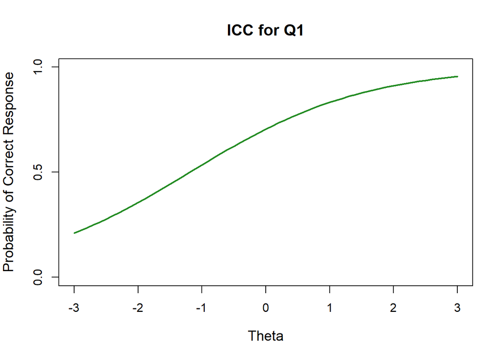

```r
icc(b = twopl_params$b[1],
    a = twopl_params$a[1],
    color = "forestgreen",
    title = "ICC for Q1")
```

You can plot multiple ICCs on the same window using `par(new = TRUE)`.

*Example*:

Let’s plot the ICC curves for Q1 using the Rasch and 2PL model estimates on the same window.

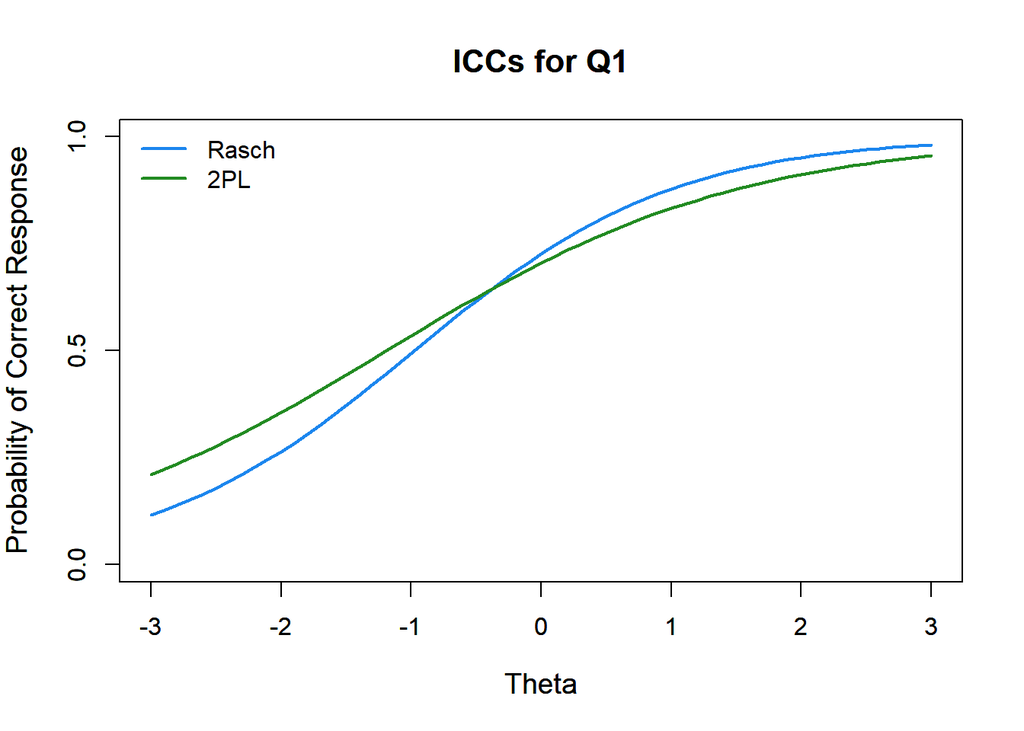

```r
# Rasch ICC
  icc(b = rasch_params$b[1],
      color = "dodgerblue2",
      title = "ICCs for Q1")

# Set par value
  par(new = TRUE)

# 2PL ICC
  icc(b = twopl_params$b[1],
      a = twopl_params$a[1],
      color = "forestgreen",
      title = "ICCs for Q1")

# Legend
  legend("topleft",
         legend = c("Rasch", "2PL"),
         lwd = 2,
         col = c("dodgerblue2", "forestgreen"),
         bty = "n")
```

#### Information

Plot test information curves using the following function:

```r
tif <- function(b, a, c, color, title) {
  J <- length(b)
  if (missing(c)) {
    c <- rep(0, J)
  }

  if (missing(a)) {
    a <- rep(1, J)
  }
  theta <- seq(-3, 3, 0.1)
  ii <- matrix(rep(0, length(theta)*J), nrow=length(theta))
  i <- rep(0, length(theta))
  for (j in 1:J) {
    Pstar <- 1 / (1 + exp(-a[j] * (theta - b[j])))
    P <- c[j] + (1 - c[j]) * Pstar
    ii[,j] <- a[j]**2 * P * (1.0 - P) * (Pstar / P)**2
    i <- i + ii[,j]
  }

  plot(theta,
       i,
       xlim = c(-3,3),
       type = "l",
       xlab = "Ability",
       ylab = "Information",
       col = color,
       cex.lab = 1.2,
       lwd = 2,
       ylim = c(0, max(i)),
       main = title,
       cex.main = 1.3)
}
```

*Example*:

Let’s plot the test information curve for our Rasch item parameter estimates.

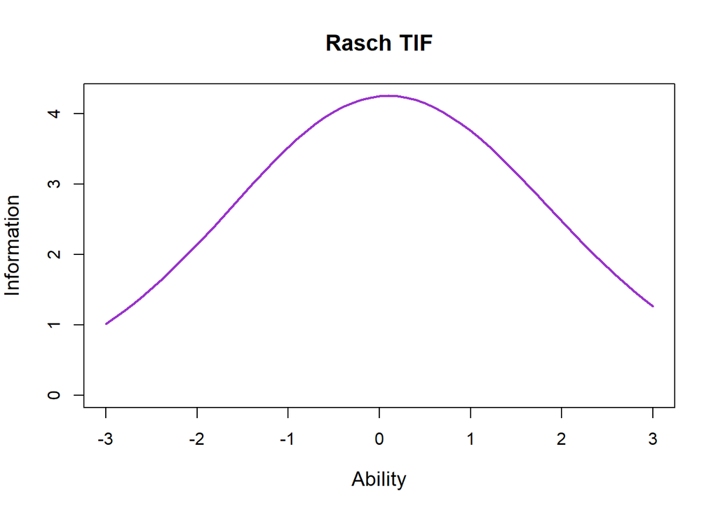

```r
tif(b = rasch_params$b,
    color = "darkorchid",
    title = "Rasch TIF")
```

#### TCCs

Plot test characteristic curves using the following function:

```r
tcc <- function(b, a, c, color, title) {
  J <- length(b)
  if (missing(c)) c <- rep(0, J)
  if (missing(a)) a <- rep(1, J)
  theta <- seq(-10, 6, .001)
  ts <- rep(0, length(theta))
  for (j in 1:J) {
    P <- c[j] + (1 - c[j]) / (1 + exp(-a[j]*(theta-b[j])))
    ts <- ts + P
  }
  plot(theta,
       ts,
       type = "l",
       lwd = 2,
       col = color,
       main = title,
       xlab = "Theta",
       ylab = "Estimated Total Score")
}
```

*Example*:

Let’s make a TCC using our 2PL model estimates.

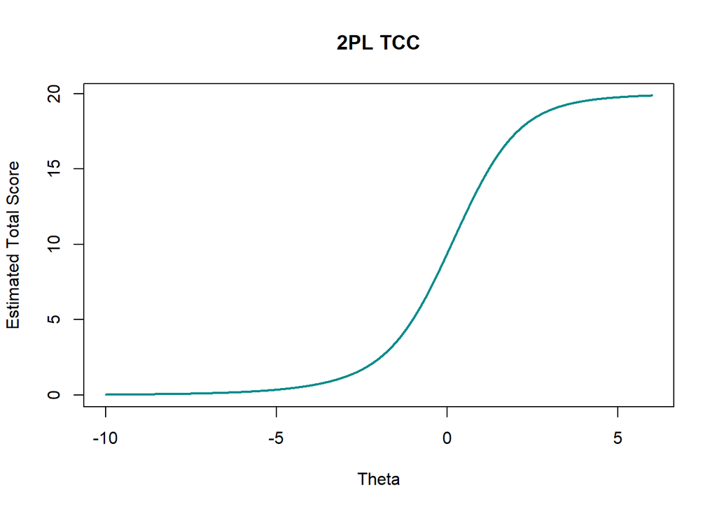

```r
tcc(b = twopl_params$b,
    a = twopl_params$a,
    color = "darkcyan",
    title = "2PL TCC")
```

#### SEM Plots

Plot the SEM by theta using the function:

```r
sem <- function(b, a, c, color, title) {
  J <- length(b)
  if (missing(c)) {
    c <- rep(0, J)
  }

  if (missing(a)) {
    a <- rep(1, J)
  }
  theta <- seq(-3, 3, 0.1)
  ii <- matrix(rep(0, length(theta)*J), nrow=length(theta))
  i <- rep(0, length(theta))
  for (j in 1:J) {
    Pstar <- 1 / (1 + exp(-a[j] * (theta - b[j])))
    P <- c[j] + (1 - c[j]) * Pstar
    ii[,j] <- a[j]**2 * P * (1.0 - P) * (Pstar / P)**2
    i <- i + ii[,j]
  }

  sem <- 1 / sqrt(i)

  plot(theta,
       sem,
       xlim = c(-3, 3),
       ylim = c(0, 1.6),
       cex.lab = 1.2,
       type = "l",
       lwd = 2,
       col = color,
       xlab = "Ability",
       ylab = "SEM",
       main = title,
       cex.main = 1.3)
}
```

*Example*:

Let’s plot the SEM for our 2PL model.

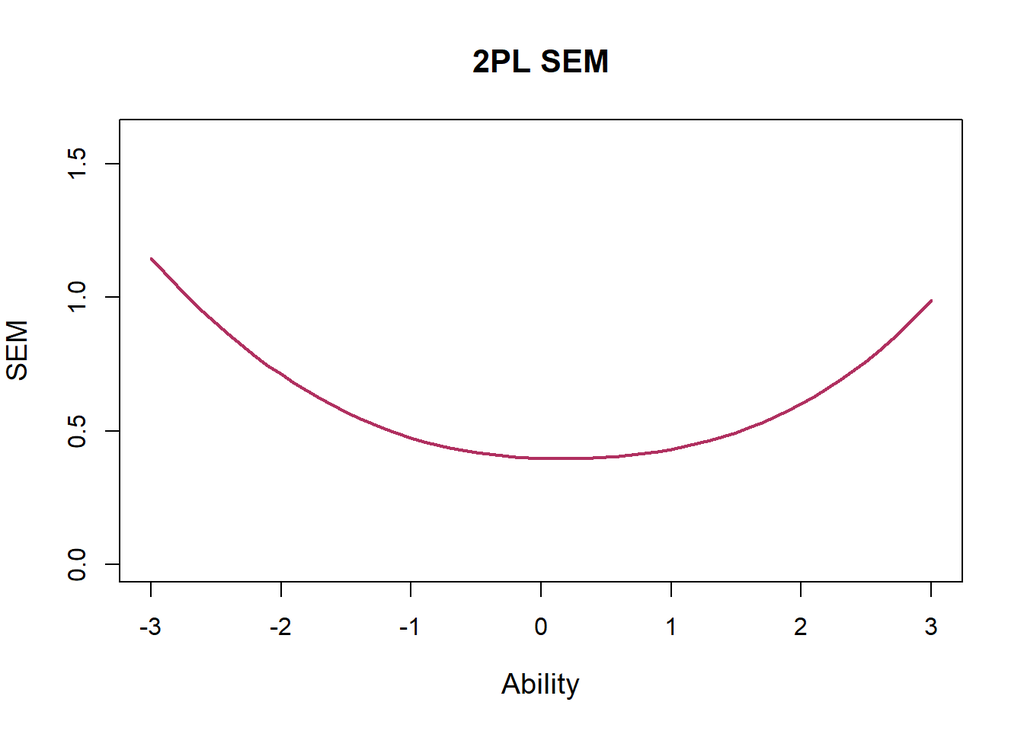

```r
sem(b = twopl_params$b,
    a = twopl_params$a,
    color = "maroon",
    title = "2PL SEM")
```

#### Wright Maps

Use the `wrightMap` function in the **WrightMap** package to create a Wright map for your data. It will automatically return the item parameters as well, unless you use the `return.thresholds = FALSE` option.

*Warning*: If you run the code multiple times to change options, it will start to decrease the size of the map in your plot window. I’m not sure how to fix this without just restarting RStudio…

*Basic Code*: `wrightMap(thetas, item_params)`

*Example*:

Let’s make a Wright map for our Rasch data. When you make this in RStudio, make sure you resize your plot pane to accomodate your item names.

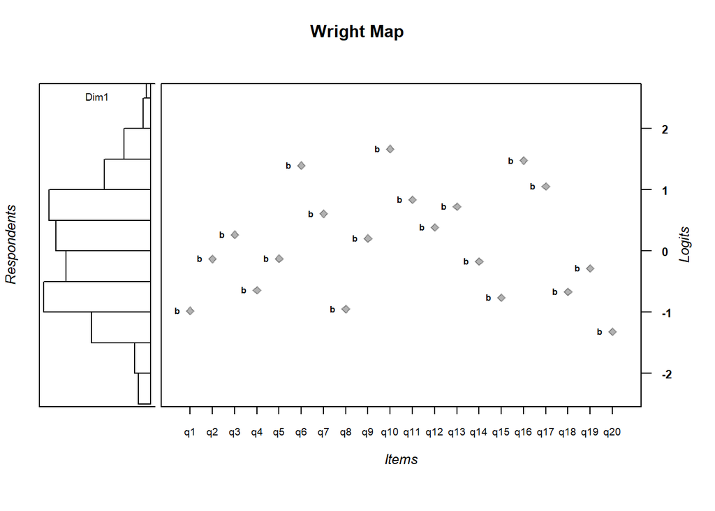

```r
wrightMap(rasch_theta$theta,
          rasch_params,
          return.thresholds = FALSE)
```

##### Text Options

1. Title

Use the `main.title` option to give your Wright map a new title

*Example*:

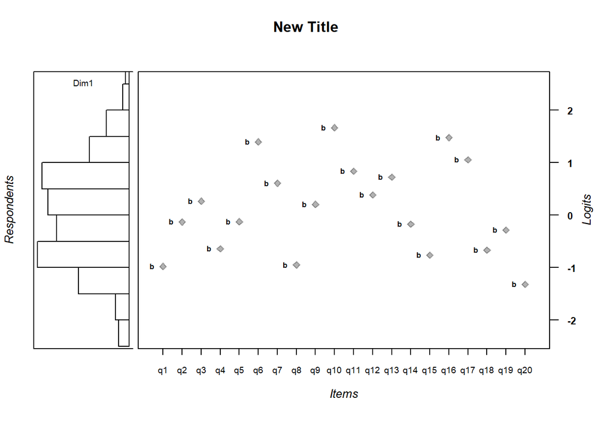

```r
wrightMap(rasch_theta$theta,
          rasch_params,
          return.thresholds = FALSE,
          main.title = "New Title")
```

2. Axis labels

Use the following options to change the three lables

- `axis.logits` changes the label on the right
- `axis.persons` changes the label on the the left
- `axis.items` changes the label on the bottom

*Example*:

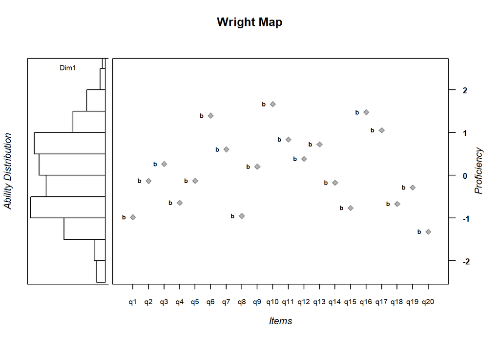

```r
wrightMap(rasch_theta$theta,
          rasch_params,
          return.thresholds = FALSE,
          axis.logits  = "Proficiency",
          axis.persons = "Ability Distribution",
          axis.items   = "Items")
```

3. Symbol Labels

The default is to have the data points labled. You can get rid of the labels using the `show.thr.lab = FALSE` option.

*Example*:

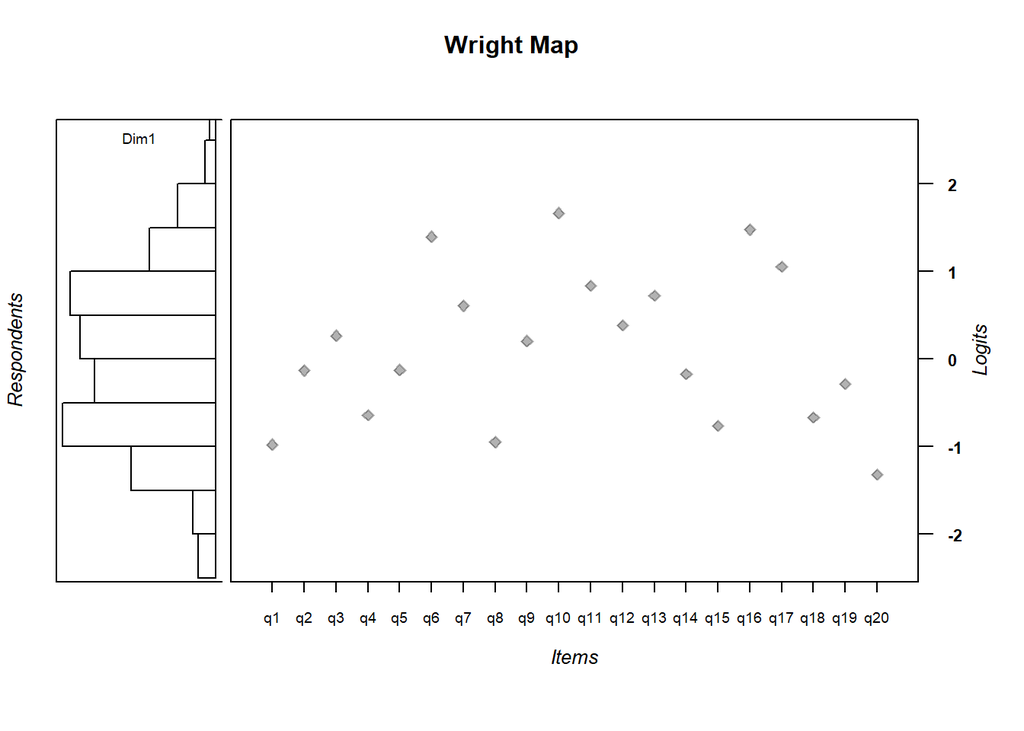

```r
wrightMap(rasch_theta$theta,
          rasch_params,
          return.thresholds = FALSE,
          show.thr.lab = FALSE)
```

##### Plot options

1. Histogram vs Density Line

The default is to make a histogram of the person estimates. To make a density line instead, use the `use.hist = FALSE` option.

*Example*:

```
## Parameter 'use.hist' is deprecated. Please use 'person.side' parameter instead.
```

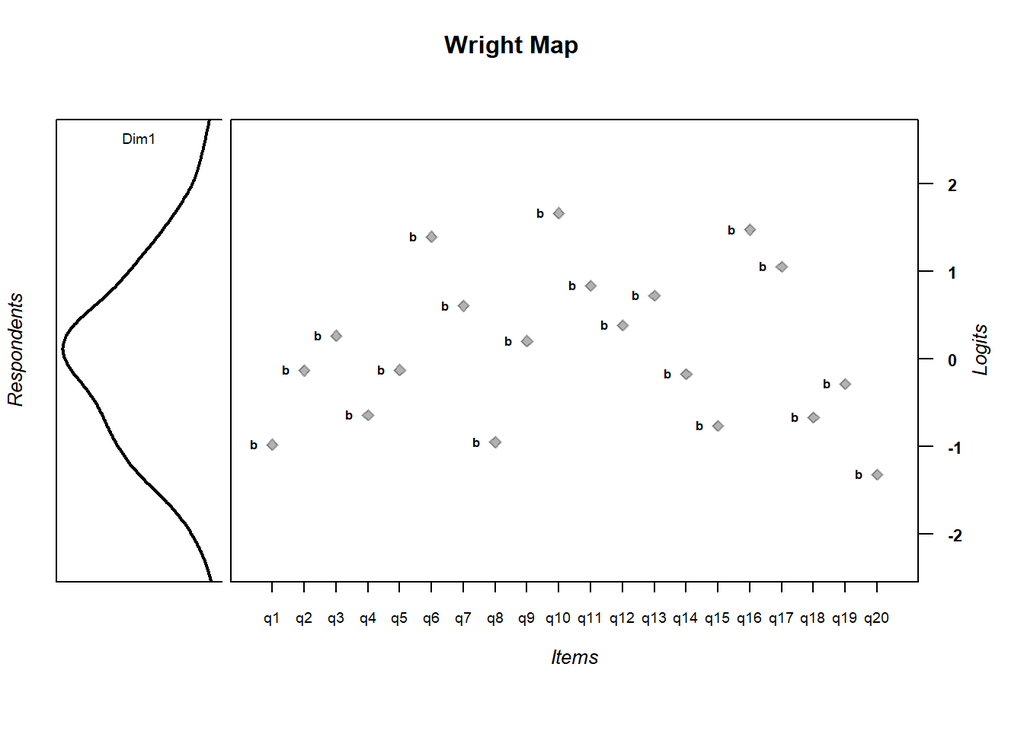

```r
wrightMap(rasch_theta$theta,
          rasch_params,
          return.thresholds = FALSE,
          use.hist = FALSE)
```

2. Data Points

Use the following options to change the look of the data points on the item side:

- `thr.sym.pch` changes the symbol shape
- `thr.sym.cex` changes the symbol size
- `thr.sym.col.fg` changes the symbol color

See `?WrightMap::item.side` for more options

Use these options to change the histogram/density line on the person side:

- `dim.col` changes the color of the histogram bars or density line. You can use a vector to specify a different color for each dimension, if you have multiple.
- `dim.names` lets you change the list of dimension names displayed at the top

See `?WrightMap::person.side` for more options

*Example*:

Lets make the data points green squares and make them 1.5 times as large. We’ll also make the histogram gold and remove the dimension name, since we only have one.

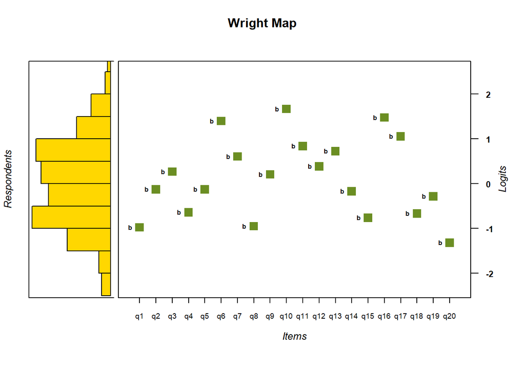

```r
wrightMap(rasch_theta$theta,
          rasch_params,
          return.thresholds = FALSE,
          thr.sym.pch = 15,
          thr.sym.cex = 1.5,
          thr.sym.col.fg = "olivedrab",
          dim.col = "gold",
          dim.names = "")
```